# Actuarial Data Science Immersion - Ausarbeitung Teil 1

## 3.4 c) 6 Multi-feature comparisons

Zur Erstellung der Korrelationsmatrix werden nur jene Merkmale berücksichtig, die mehr als eine Ausprägung haben.

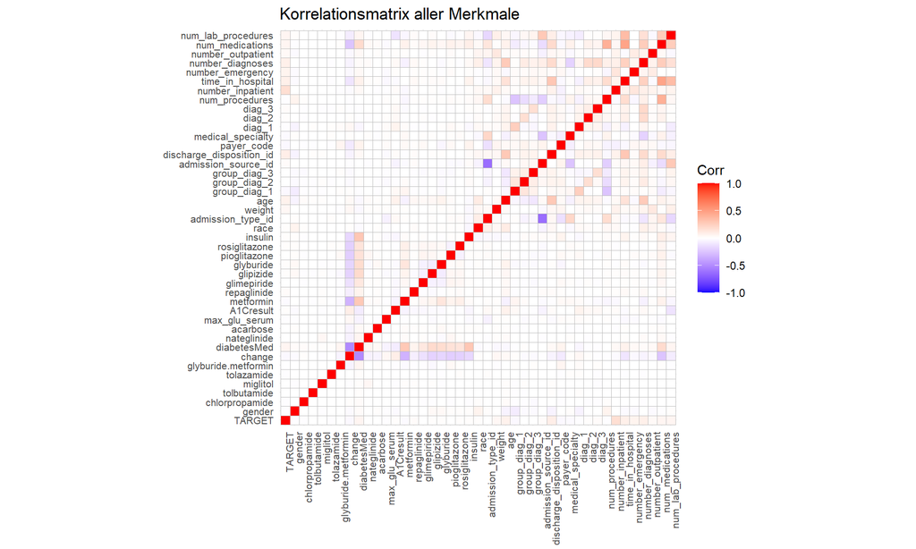

```r
diabetic_data_bin_num <- diabetic_data_bin %>%
  dplyr::select(
    dplyr::all_of(merkmale_info %>%
                    dplyr::filter(Gruppe != "Gruppe_1") %>%
                    dplyr::pull(Merkmal)))

diabetic_data_bin_num <-
  data.frame(lapply(diabetic_data_bin_num, function(x) {
    if (is.factor(x)) {
      as.integer(x)
    } else {
      x
    }
  })) %>%
  dplyr::select(TARGET, dplyr::everything())

corr_matrix <- cor(diabetic_data_bin_num)
ggcorrplot::ggcorrplot(corr_matrix, lab = FALSE, tl.cex = 8) +
  labs(title = "Korrelationsmatrix aller Merkmale") +
  theme(axis.text.x = element_text(angle = 90, hjust = 1))
```

Die Korrelationsmatix ist aufgrund der hohen Anzahl an Merkmalen unübersichtlich. Deshalb werden im nächsten Schritt nur jede Merkmale gefiltert, die mit zumindest einem anderen Merkmal eine hohe Korrelation (positiv oder negativ) aufweisen. Diese Merkmale werden in einer neuen Korrelationsmatrix übersichtlicher dargestellt. Als Schwellwert für die Korrelation wird 0.25 verwendet.

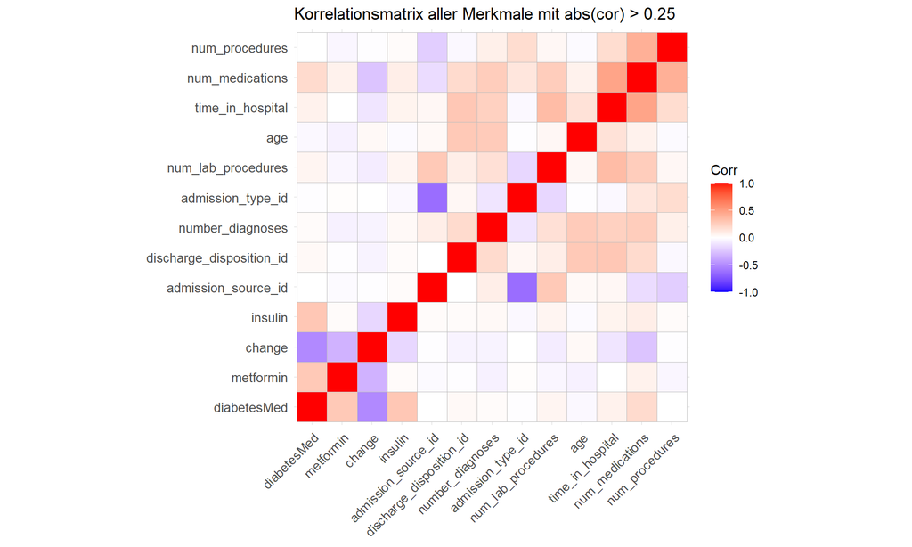

```r
schwellwert <- 0.25
high_corr <- (abs(corr_matrix) >= schwellwert) & (corr_matrix != 1)
high_corr_pairs <- which(high_corr, arr.ind = TRUE)

ggcorrplot::ggcorrplot(cor(diabetic_data_bin_num[,unique(rownames(high_corr_pairs))]), lab = FALSE, tl.cex = 10) +
  labs(title = "Korrelationsmatrix aller Merkmale mit abs(cor) > 0.25")
```

Die *TARGET*-Variable ist in dieser Auswertung nicht enthalten, d.h. keines der Merkmale hat eine stärkere Korrelation (Schwellwert 0.25) mit der Zielvariable. Damit kann ausschließlich aus der Korrelations-Analyse keine Aussage über signifikante Merkmale für die Prognose der Zielvariable getroffen werden.

Eine Korrelation (absolut) größer als 0.5 weisen nur zwei Merkmalpaare auf, wie folgende Auswertung bzw. Grafik zeigt (*admission_source_id* mit *admission_type_id* bzw. *change* mit *diabetesMed*):

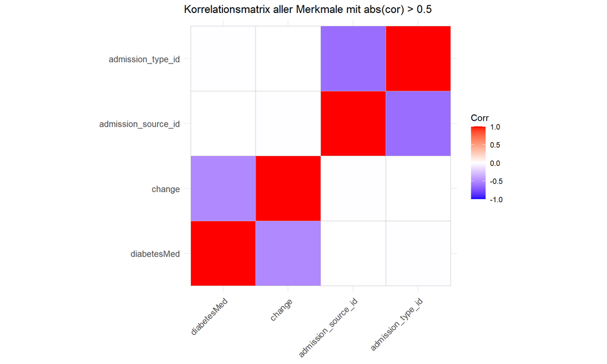

```r
schwellwert <- 0.5
high_corr <- (abs(corr_matrix) >= schwellwert) & (corr_matrix != 1)
high_corr_pairs <- which(high_corr, arr.ind = TRUE)

ggcorrplot::ggcorrplot(cor(diabetic_data_bin_num[,unique(rownames(high_corr_pairs))]), lab = FALSE, tl.cex = 10) +
  labs(title = "Korrelationsmatrix aller Merkmale mit abs(cor) > 0.5")
```

Insgesamt zeigen sich, dass die Merkmale untereinander wenig korreliert sind, bzw. nur eine gringe Korrelation mit der Zielvariable *TARGET* ausweisen.

# 4 R3: Datenaufteilung und XGBoost

## 4.1 a) Datenaufteilung

*Stratifizierter Split* des gesamten Datensatz in einen Trainings-, Validierungs- und Testdatensatz bedeutet, dass annähernd dieselbe prozentuale Aufteilung der Ausprägungen der betrachteten Splitvariable im Trainings-, Validierungs- und Testdatensatz vorhanden sind. In unserem Fall soll für die Variable *TARGET* diese Vorgabe erfüllt sein.

Nachdem zwei Datensätze - *diabetic_data_ter* und *diabetic_data_bin* - aufgeteilt werden müssen, wird eine Split-Funktion definiert bzw. verwendet.

```r
split_data <- function(data) {
  # Für die Reproduzierbarkeit wird vor dem zufälligen Ziehen in der Funktion "stratified" der Zufallsgenerator gesetzt.
  # Für die Überprüfung des Splits wird eine Nummerierungs-Spalte eingefügt, die danach wieder gelöscht wird.

  rueckgabe <- list()

  data_num <- data %>%
    dplyr::mutate(nr = 1:n())

  set.seed(1234)
  list_split <- splitstackshape::stratified(data_num, "TARGET", 0.7, bothSets = TRUE)
  train_data <- list_split$SAMP1 %>%
    data.frame()

  # Nach dem ersten Split enthält das Listenelement SAMP1 70% der Beobachtungen und wird für den Trainingsdatensatz verwendet.
  # Das Listenelement SAMP2 enthält 30% der Beobachtungen und enthält die Daten für den Validierungs- und Testdatensatz.
  # Dieser Datensatz wird nun stratifiziert 50 / 50 aufgeteilt.

  set.seed(1234)
  list_split <- splitstackshape::stratified(list_split$SAMP2, "TARGET", 0.5, bothSets = TRUE)
  val_data <- list_split$SAMP1 %>%
    data.frame()
  test_data <- list_split$SAMP2 %>%
    data.frame()

  # Zusammenstellung der Rückgabe-Liste
  # Zusätzlich wird überprüft, ob die eindeutige ("unique") Anzahl der "nr"-Einträge in den drei Dateien gleich
  # der Zeilenanzahl der Ursprungsdatei ist. Damit wird sichergestellt, dass jede Zeilenanzahl genau ein Mal in den drei
  # Datensätzen vorkommt.

  rueckgabe$split_test <- (length(unique(c(train_data$nr, val_data$nr, test_data$nr))) == nrow(data_num))
  rueckgabe$train_data <- train_data %>%
    dplyr::select(-nr)
  rueckgabe$val_data <- val_data %>%
    dplyr::select(-nr)
  rueckgabe$test_data <- test_data %>%
    dplyr::select(-nr)

  return(rueckgabe)
}
```

**Aufteilung Datensatz “diabetic_data_ter”**

```r
tmp <- split_data(diabetic_data_ter)
tmp$split_test
```

```
## [1] TRUE
```

Der Test zeigt, dass alle Zeilen des Ursprungdatensatzes genau ein Mal in den drei gesplitteten Dateien vorkommt.

Zuweisung der einzelnen Dateien:

```r
train_data_ter <- tmp$train_data
val_data_ter <- tmp$val_data
test_data_ter <- tmp$test_data
```

Nach dem Split wird in etwa die folgende Aufteilung erwartet (die erste Spalte ist - bis auf Rundungsdifferenzen - die erwartete Anzahl im Trainingsdatensatz, Spalte 2 bzw. Spalte 3 die Anzahl im Validierungs- bzw. Testdatensatz).

```r
tmp <- round(table(diabetic_data_ter$TARGET) %*% t(c(0.7,0.15,0.15)),0)
colnames(tmp) <- c("Training", "Validierung", "Test")
tmp
```

```
##
##       Training Validierung Test
##   <30     4394         942  942
##   >30    15555        3333 3333
##   NO     29032        6221 6221
```

Diese erwartete Anzahl wird bis auf eine Abweichung von 1 (aufgrund der Rundungen in der obigen Auswertung) in den drei Datensätzen beobachtet:

Die Zeilenanzahl im Trainingsdatensatz ist 48.981, die Aufteilung des Merkmals *TARGET* ist:

```r
table(train_data_ter$TARGET)
```

```
##
##   <30   >30    NO
##  4394 15555 29032
```

Die Zeilenanzahl im Validierungsdatensatz ist 10.497, die Aufteilung des Merkmals *TARGET* ist:

```r
table(val_data_ter$TARGET)
```

```
##
##  <30  >30   NO
##  942 3334 6221
```

Die Zeilenanzahl im Testdatensatz ist 10.495, die Aufteilung des Merkmals *TARGET* ist:

```r
table(test_data_ter$TARGET)
```

```
##
##  <30  >30   NO
##  941 3333 6221
```

**Aufteilung Datensatz “diabetic_data_bin”**

```r
tmp <- split_data(diabetic_data_bin)
tmp$split_test
```

```
## [1] TRUE
```

Der Test zeigt, dass alle Zeilen des Ursprungdatensatzes genau ein Mal in den drei gesplitteten Dateien vorkommt.

Zuweisung der einzelnen Dateien:

```r
train_data_bin <- tmp$train_data
val_data_bin <- tmp$val_data
test_data_bin <- tmp$test_data
```

Nach dem Split wird in etwa die folgende Aufteilung erwartet (die erste Spalte ist - bis auf Rundungsdifferenzen - die erwartete Anzahl im Trainingsdatensatz, Spalte 2 bzw. Spalte 3 die Anzahl im Valdierungs- bzw. Testdatensatz).

```r
tmp <- round(table(diabetic_data_bin$TARGET) %*% t(c(0.7,0.15,0.15)),0)
colnames(tmp) <- c("Training", "Validierung", "Test")
tmp
```

```
##
##     Training Validierung Test
##   0    29032        6221 6221
##   1     4394         942  942
```

Diese erwartete Anzahl wird bis auf eine Abweichung von 1 (aufgrund der Rundungen in der obigen Auswertung) in den drei Datensätzen beobachtet:

Die Zeilenanzahl im Trainingsdatensatz ist 33.426, die Aufteilung des Merkmals *TARGET* ist:

```r
table(train_data_bin$TARGET)
```

```
##
##     0     1
## 29032  4394
```

Die Zeilenanzahl im Validierungsdatensatz ist 7.163, die Aufteilung des Merkmals *TARGET* ist:

```r
table(val_data_bin$TARGET)
```

```
##
##    0    1
## 6221  942
```

Die Zeilenanzahl im Testdatensatz ist 7.162, die Aufteilung des Merkmals *TARGET* ist:

```r
table(test_data_bin$TARGET)
```

```
##
##    0    1
## 6221  941
```

## 4.2 b) 8.3 XGBoost parameters and fitting

Die nachfolgende Funktion dient zur Umformung alle kategoriellen Merkmale (Factor-Variablen) in Integer-Variablen.

```r
fac_to_num <- function(data, logistic = TRUE) {
  # Parameter:
  #    logistic = TRUE: Für bin-Daten - die Target-Variable wird in ein Interger umgewandelt und auf 0 / 1 gesetzt
  #    logistic = FALSE: Für ter-Daten - die Target-Variable bleibt eine Faktor-Variable

  data_num <-
    data.frame(lapply(data, function(x) {
      if (is.factor(x)) {
        as.integer(x)
      } else {
        x
      }
    }))
  if (logistic == TRUE) {
    data_num$TARGET <- data_num$TARGET - 1
  } else {
    data_num$TARGET <- data$TARGET
  }

  return(data_num)
}
```

Der XGBoost-Algorithmus benötigt eine spezielle Struktur der Eingangsdaten in *xgb.DMatrix*-Format. Die Funktion zur Erzeugung des Formats erlaubt als Eingangsgrößen nur numerische Matrizen. Deshalb werden in den drei benötigten Datensätze alle kategoriellen Merkmale in numerische Werte umgewandelt.

```r
train_data_bin_num <- fac_to_num(train_data_bin, logistic = TRUE)
val_data_bin_num <- fac_to_num(val_data_bin, logistic = TRUE)
test_data_bin_num <- fac_to_num(test_data_bin, logistic = TRUE)
```

Erzeugung der drei Datensätze in *xgb.DMatrix*-Format:

```r
dtrain_bin <- xgboost::xgb.DMatrix(as.matrix(train_data_bin_num %>% dplyr::select(-TARGET), enable_categorical = TRUE),label = train_data_bin_num$TARGET)
dvalid_bin <- xgboost::xgb.DMatrix(as.matrix(val_data_bin_num %>% dplyr::select(-TARGET), enable_categorical = TRUE),label = val_data_bin_num$TARGET)
dtest_bin <- xgboost::xgb.DMatrix(as.matrix(test_data_bin_num %>% dplyr::select(-TARGET), enable_categorical = TRUE))
```

**Bemerkung:**: Der XGBoost-Algorithmus benötigte in früherer Form eine Umformung kategorieller Variablen mit *One-Hot-Encoding*. Neuere Version können mit *encodeden Variablen* bzw. sogenannten *Label-Encoding* (Umwandlung der Faktoren in 1, 2, …) umgehen. Mit dem Parameter *enable_categorical = TRUE* wird angezeigt, dass ursprünglich kategorielle Variablen im Datensatz vorhanden waren.

Ein One-Hot-Encoding aller kategorieller Variablen im Trainings-Datensatz könnte beispielsweise mit folgender Funktion durchgeführt werden (es werden nur die Formeln angeführt, sie sind allerdings auskommentiert)

```r
# Ermittlung aller Merkmale mit mehr als einer Ausprägung
# keep_col_xgb <- merkmale_info %>%
#   dplyr::filter(Anzahl > 1) %>%
#   dplyr::pull(Merkmal)
# train_data_bin_ohe <- model.matrix(~ . - 1, data = train_data_bin[,keep_col_xgb])
```

Die nachfolgende Funktion wird für die Parameteroptimierung (Anzahl der verwendeten Bäume) benötigt. Wie gefordert, wird das Gütemaß *AUC* (area under the ROC curve) verwendet.

```r
xgb_AUC <- function(preds, dtrain){
  actual <- xgboost::getinfo(dtrain, "label")
  score <- MLmetrics::AUC(preds, actual)
  return(list(metric = "AUC", value = score))
}
```

```r
xgb_params <- list(
  colsample_bytree = 1,
  subsample = 1,
  booster = "gbtree",
  max_depth = 5,
  eta = 0.3,
  eval_metric = xgb_AUC,
  objective = "reg:logistic",
  nthread = 1
)
```

Die wichtigsten Parameter für das Training eines XGBoost-Modells sind:

- **colsample_bytree**: Gibt den Anteil der Spalten / Features an, die zufällig pro Baum verwendet werden. Der Paramter hat einen Wertebereich von [0,1], wobei der Standardwert = 1.0 ist. Die Verwendung des Parameters reduziert das Overfitting und erhöht die Robustheit des Modells.
- **subsample**: Gibt den Anteil der Trainingsdaten an, die zufällig pro Baum verwendet werden. Der Paramter hat einen Wertebereich von [0,1], wobei der Standardwert = 1.0 ist. Die Verwendung des Parameters reduziert das Overfitting und erhöht die Diversität der Bäume.
- **max_depth**: Ist ein ganzzahliger Wert >0 und gibt die maximale Tiefe eines Entscheidungsbaumes vor. Mit diesem Parameter kann die Komplexität des Modells kontrolliert werden. Ein hoher Wert führt zu einem komplexeren Modell, wodurch das Risiko für Overfitting steigt.
- **eta** (auch **Lernrate** genannt): Steuert, mit welchem Gewicht die einzelnen Bäume im gesamten Modell (Assemble von Bäumen) eingehen. Der Standardwert ist 0.3, wobei ein kleiner Wert zu einem langsameren aber häufig “genaueren” Lernen führt. Im Falle eines kleinen eta sollte die Anzahl der Bäume (Parameter **nrounds**) erhöht werden.

**Bemerkung**: Wie in den vorigen Abschnitten gesehen, hat die Zielvariable ein deutliches Übergewicht in der Ausprägung 0. Dieses Übergewicht könnte mit dem Parameter *scale_pos_weight* in der Modellierung berücksicht werden, indem die Beobachtungen mit Ausprägung 1 höher gewichtet werden. Diese Möglichkeit haben auch die meisten der in den folgenden Abschnitten verwendeten Methoden, wobei hier und auch später nicht von der Möglichkeit gebraucht gemacht wird (das wäre ein Schritt im Zuge einer Modelloptimierung).

Für die nachfolgende Modellierung wird die Lernrate *eta* wie in der Ausarbeitung SWoF auf 0.3 belassen. Dies führt zu einem schnelleren Training bzw. zu einem Modell mit einer gerinen Anzahl von Entscheidungsbäumen. Damit benötigen nachfolgende Analysen, wie beispielsweise die Ermittlung von Interaktionen zwischen den Merkmalen, weniger Zeit. In einer “realen” Anwendung sollte allerdings eine Optimierung der Hyperparameter erfolgen.

Die beiden Parameter *colsample_bytree* und *subsample* werden jeweils auf 1 gesetzt (im Gegensatz zur Ausarbeitung SWoF, in der beide Parameter 0.7 sind). Der Grund ist die Ermittlung der in Aufgabe *R4: b) Logistische Regression mit Interaktionen* benötigte Interaktionen mit dem Paket *EIX* (siehe entsprechenden Abschnitt).

```r
watchlist <- list(train = dtrain_bin, valid = dvalid_bin)

set.seed(1234)
xgb_cv <- xgboost::xgb.cv(xgb_params,
                          dtrain_bin,
                          early_stopping_rounds = 5,
                          nfold = 5,
                          print_every_n = 5,
                          nrounds = 50,
                          maximize = TRUE)
```

[output not shown]

Im Gegensatz zum originalen Code wird für das Training des verwendeten Modells kein **early_stopping_rounds** verwendet, sondern die über cv ermittelte optimale Rundenanzahl (=Baumtiefe) von 30 verwendet.

```r
best_nrounds <- xgb_cv$best_iteration

set.seed(1234)
xgb_model <- xgboost::xgb.train(params = xgb_params,
                                data = dtrain_bin,
                                print_every_n = 5,
                                watchlist = watchlist,
                                nrounds = best_nrounds,
                                maximize = TRUE)
```

Berechnung der Wahrscheinlichkeit für den Wert 1 in der Zielvariable für alle Beobachtungen im Test-Datensatz:

```r
probs_xgb <- predict(xgb_model, dtest_bin)
```

Der AUC-Wert der Testdaten ist 0.6860268.

```r
MLmetrics::AUC(probs_xgb, test_data_bin$TARGET)
```

```
## [1] 0.6860268
```

## 4.3 c) 8.4 Feature Importance

Die Feature Importance wird mit Hilfe der Funktion *xgb.importance* aus dem XGBoost-Paket berechnet.

```r
imp_matrix <- tibble::as_tibble(
  xgboost::xgb.importance(feature_names = colnames(train_data_bin %>% dplyr::select(-TARGET)), model = xgb_model))  %>%
  head(20)
```

Die folgende Grafik zeigt die 20 Merkmale mit den höchsten Importance-Werte (zur übersichtlicheren Darstellung wurde die Auswertung auf die ersten 20 Merkmale beschränkt.)

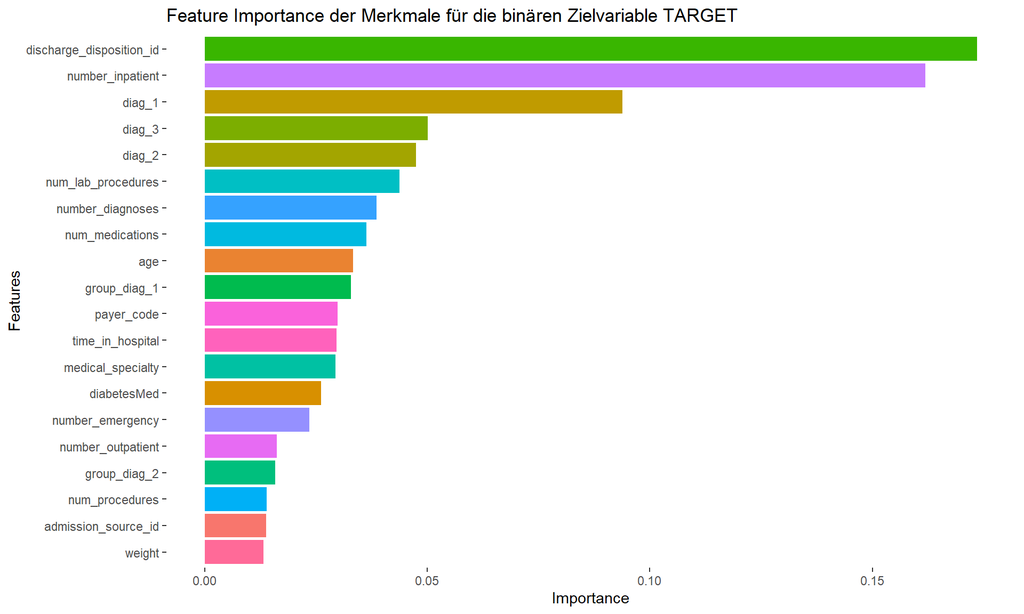

```r
imp_matrix %>%
  ggplot(aes(reorder(Feature, Gain, FUN = max), Gain, fill = Feature)) +
  geom_col() +
  coord_flip() +
  theme(legend.position = "none",
         panel.background = element_rect(fill = "white", color = NA),
         plot.background = element_rect(fill = "white", color = NA)) +
  labs(title = "Feature Importance der Merkmale für die binären Zielvariable TARGET",
       x = "Features", y = "Importance")
```

Die höchste Importance zeigen die Variablen

- *discharge_disposition_id*: Vereinbarung bzw. Entscheidung, wohin der Patient nach dem Aufenthalt entlassen wird, z.B. nach Hause, Rehabilitationsklinik, Pflegeheim, …
- *number_inpatient*: Anzahl der stationären Besuche des Patienten im Jahr vor Einweisung
- *diag_1*, *diag_2* und *diag_3*: Diagnosen
- *num_lab_procedures*: Anzahl der durchgeführten Test (während der Begegnungen)
- *number_diagnoses*: Anzahl der gestellten Diagnosen
- *num_medications*: Anzahl der Medikamente
- *age*: Alter

Die Auswertung zeigt, welche Merkmale in einen Modell jedenfalls berücksichtigt werden sollen, um eine hohe Progrosegüte der Zielvariable zu gewährleisten. Diese Merkmale sollten (nach einer genaueren Analyse der Importance der einzelnen Ausprägungen) ebenfalls in Entscheidungen über die Behandlung des Patienten berücksichtigt werden, um die Wahrscheinlichkeit einer möglichen Wiedereinweisung zu verringern.

# 5 R4: Logistische Regressionen ohne und mit Interaktionen

## 5.1 a) Logistische Regressionen ohne Interaktionen

Zunächst werden alle Merkmale / Prädiktoren ermittelt, die mindestens zwei verschiedene Ausprägungen haben. Für die Ermittlung wird die vorhin berechnete Tabelle *merkmale_info* verwendet. Danach werden die drei Diagnosenspalten *diag_1*, *diag_2* und *diag_3* - die nicht als Prädiktoren berücksichtigt werden sollen - ausgeschlossen (die Zielvariable wird in diesem Schritt nicht ausgeschlossen, da sie noch im Datensatz benötigt wird).

```r
keep_col <- merkmale_info %>%
  dplyr::filter(Anzahl > 1) %>%
  dplyr::pull(Merkmal)
keep_col <- keep_col[!(keep_col %in% c("diag_1", "diag_2", "diag_3"))]
```

Generierung des Trainings- und Testdatensatzes:

```r
train_data_glm <- train_data_bin[,keep_col]
test_data_glm <- test_data_bin[,keep_col]
```

Traing des Modells für die logistische Regression mit der Funktion *glm* und dem Parameter *family = binomial*

```r
glm_model <- glm(TARGET ~ ., data = train_data_glm, family = binomial)
```

Eine Übersicht der wichtigsten Modellgrößen und Prädiktoren wird mit der Funktion *summary()* erstellt. Dabei enthält der Abschnitt *Coefficients* für jedes Merkmal

- den Schätzwert (1. Spalte)
- die Standardabweichung (2. Spalte)
- den z-Wert = Wert der Teststatistik mit der H0-Hypothese *Prädiktor = 0* (3. Spalte)
- den p-Wert des Tests (4. Spalte)

```r
(sum_glm_model <- summary(glm_model))
```

```
##
## Call:
## glm(formula = TARGET ~ ., family = binomial, data = train_data_glm)
##
## Coefficients:
##                                                         Estimate Std. Error
## (Intercept)                                            -4.848852   1.750106
## genderMale                                             -0.047413   0.034828
## chlorpropamideSteady                                   -1.621138   1.028891
## tolbutamideSteady                                      -0.781239   1.068261
## miglitolSteady                                        -13.533345 566.091421
## tolazamideSteady                                      -13.526772 364.667627
## glyburide.metforminSteady                              -0.142012   0.222537
## changeNo                                                0.015952   0.063796
## diabetesMedYes                                          0.395714   0.062820
## nateglinideSteady                                      -0.141488   0.228633
## nateglinideUp                                         -15.084346 422.956495
## acarboseSteady                                         -0.533384   0.408047
## acarboseUp                                            -13.169695 827.711795
## max_glu_serum>300                                      -0.001886   0.216885
## max_glu_serumNone                                      -0.091247   0.159428
## max_glu_serumNorm                                       0.008631   0.179792
## A1Cresult>8                                             0.069340   0.106403
## A1CresultNone                                           0.211311   0.089676
## A1CresultNorm                                           0.052445   0.113835
## metforminNo                                            -0.254616   0.202476
## metforminSteady                                        -0.351627   0.202449
## metforminUp                                            -0.772237   0.269740
## repaglinideNo                                           0.507791   1.056448
## repaglinideSteady                                       0.883381   1.063868
## repaglinideUp                                           1.277274   1.115299
## glimepirideNo                                          -0.441632   0.323173
## glimepirideSteady                                      -0.569903   0.329628
## glimepirideUp                                          -0.456353   0.420745
## glipizideNo                                            -0.367965   0.201993
## glipizideSteady                                        -0.323688   0.202245
## glipizideUp                                            -0.339576   0.263300
## glyburideNo                                             0.260114   0.233000
## glyburideSteady                                         0.249076   0.233197
## glyburideUp                                             0.205177   0.286569
```

[output cut: 340 more lines]

```
## number_emergency                                        4.512 6.41e-06 ***
## number_diagnoses                                        6.032 1.62e-09 ***
## number_outpatient                                       1.586 0.112641
## num_medications                                         1.919 0.055036 .
## num_lab_procedures                                      1.124 0.260910
## ---
## Signif. codes:  0 '***' 0.001 '**' 0.01 '*' 0.05 '.' 0.1 ' ' 1
##
## (Dispersion parameter for binomial family taken to be 1)
##
##     Null deviance: 26015  on 33425  degrees of freedom
## Residual deviance: 23801  on 33237  degrees of freedom
## AIC: 24179
##
## Number of Fisher Scoring iterations: 14
```

In der logistischen Regression wird für jede Ausprägung eines kategoriellen Merkmals ein eigener Parameter geschätzt (bzw. ist der Parameterwert einer der Ausprägungen im *Intercept* enthalten, deshalb werden bei insgesamt *n* Ausprägungen für ein Merkmal nur die Parameter von *n-1* Ausprägungen angezeigt). Die Importance der einzelnen Ausprägungen kann mit der Funktion *varImp* aus dem Paket *caret* ermittelt werden. Die folgende Auswertung zeigt die 20 wichtigen Ausprägungen der Größe nach sortiert. Der Wert *Overall* entspricht dem Absolutwert des *z-Wert* (3. Spalte) in der *summary()*.

```r
caret::varImp(glm_model) %>%
  dplyr::arrange(desc(Overall)) %>%
  head(20)
```

```
##                                               Overall
## number_inpatient                            19.968501
## discharge_disposition_id22                  17.551930
## discharge_disposition_id3                   10.773484
## discharge_disposition_id5                    9.826527
## discharge_disposition_id2                    6.377568
## diabetesMedYes                               6.299205
## number_diagnoses                             6.031822
## group_diag_1Respiratory                      5.741580
## discharge_disposition_id28                   5.691050
## payer_codeMC                                 5.227385
## discharge_disposition_id15                   5.096338
## admission_source_id17                        4.903809
## number_emergency                             4.512308
## weight[75-100)                               4.482637
## payer_codeBC                                 4.471675
## group_diag_1Other                            4.328790
## medical_specialtyOrthopedics-Reconstructive  4.298036
## admission_source_id4                         4.272815
## medical_specialtyHematology/Oncology         4.146551
## admission_type_id6                           4.077470
```

Aus der *summary()* können die statistisch signifikanten Merkmale / Ausprägungen für ein vorgegebenes Signifikanzniveau ermittelt werden. Dies sind alle Merkmale / Ausprägungen, die einen *p-Wert* (4. Spalte) kleiner als das vorgegebene Signifikanzniveau haben. In der nachfolgenden Auswertung wird ein Signifikanzniveau von 5% (0.05) verwendet.

```r
coefs <- sum_glm_model$coefficients
signifikant_glm <- coefs[coefs[, 4] < 0.05, ]
```

Insgesamt sind 50 Ausprägungen statistisch signifikant, wobei der Intercept auch mitgezählt wurde. Die signifikanten Ausprägungen sind:

```r
signif_vars <- rownames(signifikant_glm)
signif_vars <- signif_vars[signif_vars != "(Intercept)"]
coefs[rownames(coefs) %in% signif_vars,1:2] %>%
  data.frame() %>%
  dplyr::arrange(Estimate)
```

```
##                                                     Estimate  Std..Error
## discharge_disposition_id23                       -1.00462877 0.423753117
## medical_specialtyOrthopedics-Reconstructive      -0.77277357 0.179796915
## metforminUp                                      -0.77223728 0.269739705
## payer_codePO                                     -0.73614367 0.273635266
## medical_specialtyObstetricsandGynecology         -0.73340169 0.267128364
## medical_specialtySurgery-Cardiovascular/Thoracic -0.68176229 0.239810506
## admission_source_id5                             -0.65129847 0.212532922
## payer_codeCM                                     -0.54198027 0.134588688
## admission_source_id17                            -0.54178912 0.110483327
## payer_codeCP                                     -0.44100811 0.120412587
## payer_codeBC                                     -0.42841577 0.095806558
## admission_source_id4                             -0.42219406 0.098809351
## discharge_disposition_id25                       -0.40319986 0.202003598
## group_diag_1Respiratory                          -0.35791959 0.062338173
## admission_source_id2                             -0.30920441 0.146687606
## medical_specialtyCardiology                      -0.30272059 0.087126337
## payer_codeHM                                     -0.29935803 0.086700383
## group_diag_1Musculoskeletal                      -0.27898393 0.096043767
## payer_codeUN                                     -0.27667258 0.119288304
## group_diag_1Other                                -0.24886801 0.057491359
## payer_codeMC                                     -0.24611994 0.047082806
## group_diag_1Digestive                            -0.15862089 0.070814492
## group_diag_1Injury                               -0.14690938 0.072538578
## group_diag_2Respiratory                          -0.13992520 0.065498047
## insulinSteady                                    -0.13838217 0.070424972
## time_in_hospital                                  0.01656560 0.007066098
## number_diagnoses                                  0.06782952 0.011245278
## number_emergency                                  0.15524872 0.034405610
## group_diag_2Diabetes                              0.17580172 0.060308410
## A1CresultNone                                     0.21131061 0.089676141
## discharge_disposition_id6                         0.22877275 0.056659358
## discharge_disposition_id18                        0.24646824 0.092802026
## diabetesMedYes                                    0.39571353 0.062819603
## admission_type_id6                                0.40306524 0.098851810
## medical_specialtyGastroenterology                 0.44125634 0.209997687
## medical_specialtyNephrology                       0.49506679 0.146266323
## discharge_disposition_id7                         0.51895689 0.200650863
## number_inpatient                                  0.53050873 0.026567279
## weight[75-100)                                    0.58871697 0.131332742
## discharge_disposition_id3                         0.58925988 0.054695389
## discharge_disposition_id2                         0.63254330 0.099182518
## weight[100-125)                                   0.65175410 0.183611968
## medical_specialtyOncology                         0.88834109 0.239967734
## discharge_disposition_id8                         0.96825560 0.443398852
## discharge_disposition_id5                         1.13470026 0.115473171
## medical_specialtyHematology/Oncology              1.24921537 0.301266094
## discharge_disposition_id22                        1.53812483 0.087632804
## discharge_disposition_id28                        1.79717302 0.315789362
## discharge_disposition_id15                        2.48290853 0.487194619
```

**Erkenntnisse**:

- Die logistische Regression liefert mit *number_inpatient*, *discharge_disposition_id* und *number_diagnoses* ähnliche Aussagen über die Wichtigkeit der Merkmale, wie das XGBoost-Modell im vorigen Abschnitt.
- Die höchste Signifikanz zeigt die Anzahl *number_inpatient*.
- Insgesamt sind 49 Ausprägungen statistisch signifikant (ohne Intercept). Die Auflistung dieser Ausprägungen oben zeigt, dass nicht alle Ausprägungen eines Merkmals für die Erklärung der Zielvariable signifikant sind.
- Der Schätzwert *Estimate* in der obenstehenden Tabelle zeigt an, ob die Ausprägung / Prädiktor die Wahrscheinlichkeit der Zielvariable (= Wahrscheinlichkeit für eine Wiedereinweisung) erhöht (positiver Wert) oder verringert (negativer Wert). So hat beispielsweise die Ausprägung *23* von *discharge_disposition_id* einen stark negativen Einfluss auf die Wahrscheinlichkeit einer Wiedereinweisung, die Ausprägung *15* einen stark positiven Einfluss.

**Berechnung des AUC auf den Testdaten**

Berechnung der Wahrscheinlichkeit für den Wert 1 in der Zielvariable für alle Beobachtungen im Test-Datensatz:

```r
probs_glm <- predict(glm_model, newdata = test_data_glm, type = "response")
```

Der AUC-Wert der Testdaten ist 0.6703056.

```r
MLmetrics::AUC(probs_glm, test_data_glm$TARGET)
```

```
## [1] 0.6703056
```

Die Wahl des Schwellwertes ist vor allem bei unbalancierte binäre Kenngrößen von entscheidender Bedeutung, da er direkten und starken Einfluss auf die Sensitivität (True Positive Rate) und Spezifität (True Negative Rate) hat. Bei unbalancierten Daten neigen Modelle häufig dazu, die *negative Klasse* (= die häufer vorkommende Klasse, im Falle der Zielvariable also 0) zu bevorzugen, was zu einer hohen Spezifität aber niedriger Sensitivität führt. Die *positive Klasse* (= die seltenere Klasse, im Falle der Zielvariable also 1) wird hingegen vernachlässigt. Das passiert vor allem, wenn ein Schwellwert hoch (z.B. 0.5) gewählt wird, da das Modell nur dann positiv klassifiziert, wenn die Wahrscheinlichkeit für den Wert 1 über 0.5 liegt - das ist bei einem unbalancierten Datensatz allerdings aufgrund der Bevorzugung der negativen Klasse, häufig nicht der Fall.

**Bemerkung:**

- *Sensitivität*: misst die Fähigkeit des Modells, die positiven Fälle korrekt zu identifizieren (wichtig in medizinischen Tests, bei denen Krankheiten - oder wie im vorliegenden Fall eine Wiedereinweisung - selten vorkommen).
- *Spezifität*: misst, wie gut das Modell negative Fälle korrekt identifiziert.

**Berechnung der Konfusionsmatrix mit Schwellwert 0.5**

```r
predicted_class_glm <- ifelse(probs_glm >= 0.5, 1, 0)
conf_mat <- caret::confusionMatrix(factor(predicted_class_glm), factor(test_data_glm$TARGET), positive = "1")
conf_mat$table
```

```
##           Reference
## Prediction    0    1
##          0 6194  900
##          1   27   41
```

Die positive Klasse (die seltenere Klasse), kann in der Funktion *confusionMatrix* mit dem Parameter *positive* vorgegeben werden.

Grafische Darstellung der Konfusionsmatrix:

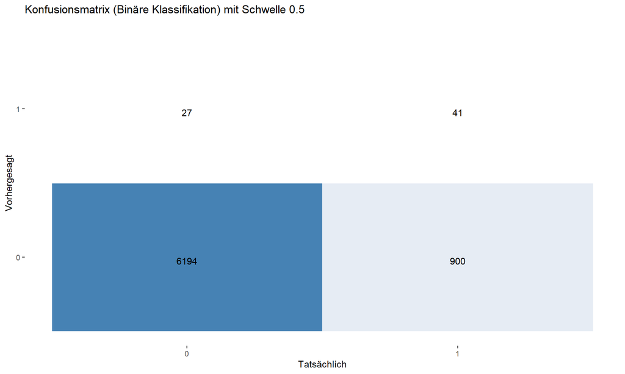

```r
cm_table <- as.data.frame(conf_mat$table)

ggplot(data = cm_table, aes(x = Reference, y = Prediction)) +
  geom_tile(aes(fill = Freq), color = "white") +
  geom_text(aes(label = Freq), vjust = 1) +
  scale_fill_gradient(low = "white", high = "steelblue") +
  theme(legend.position = "none",
        panel.background = element_rect(fill = "white", color = NA),
        plot.background = element_rect(fill = "white", color = NA)) +
  labs(title = "Konfusionsmatrix (Binäre Klassifikation) mit Schwelle 0.5",
       x = "Tatsächlich", y = "Vorhergesagt")
```

Mit dem hohen Schwellwert von 0.5 werden fast alle Testfällt mit 0 vorhergesagt. Die Sensitivität beträge 0.04357, die Spezifität 0.99566.

**Berechnung der Konfusionsmatrix mit Schwellwert 0.2**

```r
predicted_class_glm <- ifelse(probs_glm >= 0.2, 1, 0)
conf_mat_glm <- caret::confusionMatrix(factor(predicted_class_glm), factor(test_data_glm$TARGET), positive = "1")
conf_mat_glm$table
```

```
##           Reference
## Prediction    0    1
##          0 5484  660
##          1  737  281
```

Grafische Darstellung der Konfusionsmatrix:

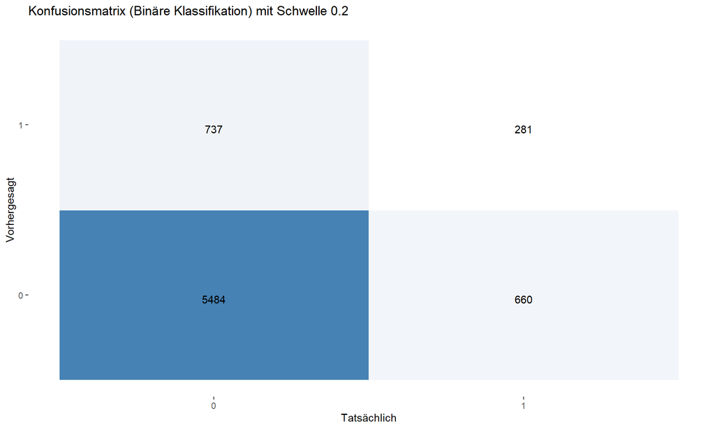

```r
cm_table <- as.data.frame(conf_mat_glm$table)

ggplot(data = cm_table, aes(x = Reference, y = Prediction)) +
  geom_tile(aes(fill = Freq), color = "white") +
  geom_text(aes(label = Freq), vjust = 1) +
  scale_fill_gradient(low = "white", high = "steelblue") +
  theme(legend.position = "none",
        panel.background = element_rect(fill = "white", color = NA),
        plot.background = element_rect(fill = "white", color = NA)) +
  labs(title = "Konfusionsmatrix (Binäre Klassifikation) mit Schwelle 0.2",
       x = "Tatsächlich", y = "Vorhergesagt")
```

Die Anzahl der korrekten Prognosen 1 ist deutlich erhöht. Die Sensitivität ist auf 0.29862 gestiegen, die Spezifität beträgt 0.88153.

Im folgenden ist eine Analyse von Sensitivität (Sensitivity) und Spezifität (Specificity) in Abhängigkeit vom Schwellwert dargestellt.

```r
show_sensi <- function(probs) {
  lapply(seq(0.05,.95,0.05), function(sw) {
    predicted_class <- ifelse(probs >= sw, 1, 0)
    predicted_class_fac <-
      factor(predicted_class, levels = 0:1, labels = levels(test_data_glm$TARGET))
    conf_mat <- caret::confusionMatrix(predicted_class_fac, factor(test_data_glm$TARGET), positive = "1")

    list(
      Schwelle = sw,
      Sensitivity = conf_mat$byClass["Sensitivity"],
      Specificity = conf_mat$byClass["Specificity"],
      Accuracy = conf_mat$overall["Accuracy"]
    )
  }) %>%
    dplyr::bind_rows() %>%
    data.frame()
}
show_sensi(probs_glm)
```

```
##    Schwelle Sensitivity Specificity  Accuracy
## 1      0.05 0.962805526  0.09853721 0.2120916
## 2      0.10 0.747077577  0.49172159 0.5252723
## 3      0.15 0.476089267  0.75502331 0.7183748
## 4      0.20 0.298618491  0.88153030 0.8049428
## 5      0.25 0.213602550  0.93650538 0.8415247
## 6      0.30 0.153028693  0.96061726 0.8545099
## 7      0.35 0.119022317  0.97669185 0.8640045
## 8      0.40 0.091392136  0.98649735 0.8688914
## 9      0.45 0.060573858  0.99244494 0.8700084
## 10     0.50 0.043570670  0.99565986 0.8705669
## 11     0.55 0.035069075  0.99710657 0.8707065
## 12     0.60 0.025504782  0.99839254 0.8705669
## 13     0.65 0.017003188  0.99935702 0.8702876
## 14     0.70 0.012752391  0.99935702 0.8697291
## 15     0.75 0.008501594  0.99967851 0.8694499
## 16     0.80 0.005313496  0.99967851 0.8690310
## 17     0.85 0.004250797  0.99983925 0.8690310
## 18     0.90 0.003188098  1.00000000 0.8690310
## 19     0.95 0.002125399  1.00000000 0.8688914
```

## 5.2 b) Logistische Regression mit Interaktionen

Zunächst werden die Wechselwirkungen zwischen den Prädiktoren des XGBoost-Modells mit Hilfe der Funktion *hstats* des gleichnamigen Pakets bestimmt bzw. analysiert.

In der Funktion *hstats* werden Interaktionen zwischen Variablen basierend auf der sogenannten *zweidimensionalen zentrierten Partial Dependence Function (PDP)* geschätzt. Die *PDP* zeigt den durchschnittlichen Effekt einer oder mehrerer Variablen auf die Modellvorhersage, indem man den Wert für die Variablen fixiert und über alle anderen Variablen mittelt.

Die *zweidimensionale zentrierte PDP* zeigt die gemeinsame Wirkung zweier Variablen, indem der durchschnittliche Effekt jeder einzelnen Variablen entfernt wird (d.h. die Variablen werden zentriert). Damit zeigt der Wert nur die Interaktion der Variablen und nicht den gesamten Haupteffekt.

Standardmäßig werden Interaktionen nur zwischen fünf Merkmalen berechnet. Die Auswahl der dabei betrachteten Merkmale erfolgt Anhand der allgemeinen Interaktionsstärke des Merkmals, bestimmt durch die sogenannte [Friedman’s H-Statistik](https://christophm.github.io/interpretable-ml-book/interaction.html). Eine größere Anzahl von Interaktionen kann durch den Parameter *pairwise_m* eingestellt werden, der angibt, für wie viele Merkmale der paarweise Interaktionswert berechnet werden soll. Für die benötigte Analyse wird die Interaktion zwischen allen Merkmalen berechnet.

Im Folgenden werden nur Interaktionen zwischen Merkmalen untersucht, die zumindest zwei Ausprägungen haben bzw. werden auch die drei Merkmale *diag_1*, *diag_2* und *diag_3* ausgeschlossen. Die Liste dieser Merkmale ist in der Variable *keep_col* gespeichert. Aus dieser Liste wird auch noch die Variable *TARGET* herausgenommen.

```r
keep_col_h2 <- keep_col[!(keep_col == "TARGET")]
```

**Bemerkung**: Die Interaktionen werden nicht auf Basis aller Beobachtungen ermittelt, sondern auf einer Stichprobe von 500 (deshalb muss zur Reproduzierbarkeit der Zufallsgenerator gesetzt werden). Die Anzahl der verwendeten Beobachtungen kann durch den Parameter *n_max* festgelegt werden. Eine Erhöhung des Parameters führt zu einer deutlichen Erhöhung der Laufzeit.

```r
set.seed(1234)
hs <- hstats::hstats(xgb_model, as.matrix(train_data_bin_num %>% dplyr::select(-TARGET)), v = keep_col_h2,
                     pairwise_m = length(keep_col_h2))
```

Die Interaktionen der einzelnen Merkmale werden über die Funktion *h2_pairwise* ausgelesen.

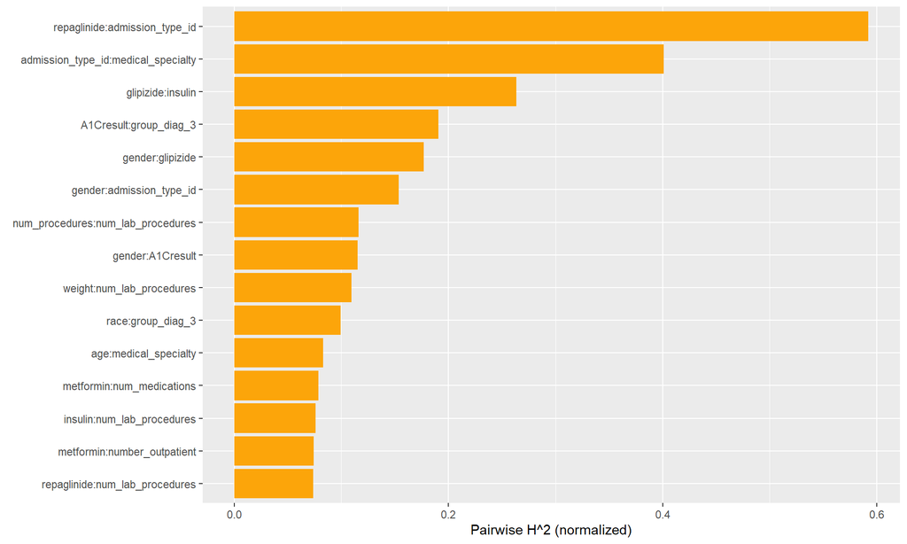

```r
h2_pw <- hstats::h2_pairwise(hs)
plot(h2_pw)
```

Die folgende Tabelle zeigt die 10 höchsten Interaktionen zwischen den Merkmalen.

```r
interactions_h2 <- data.frame(h2_pw$M) %>%
  tibble::rownames_to_column(var = "inter")
head(interactions_h2, 10)
```

```
##                                  inter    h2_pw.M
## 1        repaglinide:admission_type_id 0.59195315
## 2  admission_type_id:medical_specialty 0.40096255
## 3                    glipizide:insulin 0.26347234
## 4               A1Cresult:group_diag_3 0.19058103
## 5                     gender:glipizide 0.17707305
## 6             gender:admission_type_id 0.15369263
## 7    num_procedures:num_lab_procedures 0.11622378
## 8                     gender:A1Cresult 0.11513714
## 9            weight:num_lab_procedures 0.10949643
## 10                   race:group_diag_3 0.09948175
```

Eine weitere Möglichkeit, Interaktionen zwischen zwei Merkmalen zu untersuchen, bietet das Paket *EIX* (“Explain Interactions in XGBoost”). In der Funktion *interactions* aus diesem Paket werden alle Splits (“Eltern- / Kindknoten”-Beziehungen der Merkmale) untersucht und der sogenannte *Gain* eines Splits ermittelt. Der Gain berechnet sich aus der Summe der *Similarity Scores* der beiden Knoten nach dem Split, minus dem *Similarity Score* des Ursprungsknoten, wobei der Similarity Score die quadrierte Summe der Residuen in einem Knoten dividiert durch die Anzahl der Beobachtungen in diesem Knoten ist. Eine gute und übersichtliche Darstellung findet sich in [XGBoost — How does this work](https://medium.com/@prathameshsonawane/xgboost-how-does-this-work-e1cae7c5b6cb).

**Bemerkungen**:

- Der Vorteil der Verwendung von *EIX* anstelle von *hstats* ist, dass das Ergebnis von *EIX* nicht von der gewählten Stichprobe abhängt. So ergibt sich beispielsweise in *hstats* bei einer größeren Stichprobe mit *n_max = 5000* ein geändertes Ergebnis. In *EIX* hingegen wird die gesamte Struktur des Modells / Entscheidungsbaum berücksichtig.
- Die Funktion *interactions* rechnet leider bei größeren Bäumen sehr lange. Aufgrund der gewählten hohen Lernrate von 0.3 ist der oben entwickelte Entscheidungsbaum allerdings “klein”, wodurch die Rechenzeit von *interactions* gering ist.

```r
Inter <- EIX::interactions(xgb_model, dtrain_bin, option = "pairs")
```

Die durch das Paket *EIX* ermittelten Interaktionen sind nicht symmetrisch, d.h. die Interaktion von Merkmal A zu Merkmal B kann einen anderen Wert als die ermittelte Interaktion von Merkmal B zu Merkmal A haben. Deshalb werden die beiden ermittelten Werte “Merkmal A zu Merkmal B” und “Merkmal B zu Merkmal A” summiert.

```r
interactions_EIX <- data.frame(Inter) %>%
  dplyr::filter(!(Parent %in% c("diag_1", "diag_2", "diag_3")),
                !(Child %in% c("diag_1", "diag_2", "diag_3"))) %>%
  dplyr::filter(Parent != Child) %>%
  dplyr::mutate(inter = ifelse(Parent < Child,
                               stringr::str_c(Parent, Child, sep = ":"),
                               stringr::str_c(Child, Parent, sep = ":"))) %>%
  dplyr::group_by(inter) %>%
  dplyr::reframe(sumGain = sum(sumGain)) %>%
  dplyr::arrange(desc(sumGain)) %>%
  data.frame()
```

Im Folgenden werden die höchsten von *hstats* und *EIX* ermittelten Interaktionen gegenübergestellt.

```r
head(interactions_h2, 10)
```

```
##                                  inter    h2_pw.M
## 1        repaglinide:admission_type_id 0.59195315
## 2  admission_type_id:medical_specialty 0.40096255
## 3                    glipizide:insulin 0.26347234
## 4               A1Cresult:group_diag_3 0.19058103
## 5                     gender:glipizide 0.17707305
## 6             gender:admission_type_id 0.15369263
## 7    num_procedures:num_lab_procedures 0.11622378
## 8                     gender:A1Cresult 0.11513714
## 9            weight:num_lab_procedures 0.10949643
## 10                   race:group_diag_3 0.09948175
```

```r
head(interactions_EIX, 10)
```

```
##                                        inter   sumGain
## 1  discharge_disposition_id:number_inpatient 799.44686
## 2  discharge_disposition_id:number_diagnoses  98.30502
## 3       diabetesMed:discharge_disposition_id  65.84502
## 4          number_diagnoses:number_inpatient  64.34952
## 5         num_lab_procedures:num_medications  54.52246
## 6                            age:diabetesMed  54.51785
## 7           num_medications:time_in_hospital  50.87848
## 8      discharge_disposition_id:group_diag_1  50.64720
## 9               age:discharge_disposition_id  49.38296
## 10                      age:number_diagnoses  45.21303
```

Für die nachfolgenden Auswertung werden die drei höchsten Korrelationen aus *EIX* verwendet:

```r
formula_string <- stringr::str_c("TARGET ~ . + ", stringr::str_c(interactions_EIX$inter[1:3], collapse  = " + "), collapse  = "")
(formula <- as.formula(formula_string))
```

```
## TARGET ~ . + discharge_disposition_id:number_inpatient + discharge_disposition_id:number_diagnoses +
##     diabetesMed:discharge_disposition_id
```

```r
glm_model_inter <- glm(formula, data = train_data_glm, family = binomial)
```

```
## Warning: glm.fit: Angepasste Wahrscheinlichkeiten mit numerischem Wert 0 oder 1
## aufgetreten
```

**Bemerkung**: Beim Fit wird die Warnmeldung *glm.fit: Angepasste Wahrscheinlichkeiten mit numerischem Wert 0 oder 1 aufgetreten* angezeigt. Dass bedeutet, dass für zumindest eine Beobachtung die exakten Wahrscheinlichkeiten 0 oder 1 berechnet wurden. Diese Warnmeldung kann durch einen regularisierten Ansatz (z.B. Lasso- oder Ridge-Regression), mit dem die Schätzungen stabilisiert werden, vermieden werden.

```r
(sum_glm_model_inter <- summary(glm_model_inter))
```

```
##
## Call:
## glm(formula = formula, family = binomial, data = train_data_glm)
##
## Coefficients:
##                                                         Estimate Std. Error
## (Intercept)                                           -5.094e+00  1.755e+00
## genderMale                                            -4.599e-02  3.494e-02
## chlorpropamideSteady                                  -1.634e+00  1.032e+00
## tolbutamideSteady                                     -8.487e-01  1.073e+00
## miglitolSteady                                        -1.341e+01  5.614e+02
## tolazamideSteady                                      -1.350e+01  3.614e+02
## glyburide.metforminSteady                             -1.348e-01  2.228e-01
## changeNo                                               1.980e-02  6.399e-02
## diabetesMedYes                                         4.184e-01  7.543e-02
## nateglinideSteady                                     -1.565e-01  2.298e-01
## nateglinideUp                                         -1.537e+01  4.117e+02
## acarboseSteady                                        -5.335e-01  4.099e-01
## acarboseUp                                            -1.317e+01  8.245e+02
## max_glu_serum>300                                     -1.603e-02  2.184e-01
## max_glu_serumNone                                     -8.261e-02  1.603e-01
## max_glu_serumNorm                                     -7.146e-03  1.805e-01
## A1Cresult>8                                            6.096e-02  1.065e-01
## A1CresultNone                                          2.085e-01  8.975e-02
## A1CresultNorm                                          3.992e-02  1.140e-01
## metforminNo                                           -2.510e-01  2.035e-01
## metforminSteady                                       -3.479e-01  2.035e-01
## metforminUp                                           -7.620e-01  2.706e-01
## repaglinideNo                                          4.668e-01  1.057e+00
## repaglinideSteady                                      8.366e-01  1.064e+00
## repaglinideUp                                          1.263e+00  1.116e+00
## glimepirideNo                                         -4.151e-01  3.272e-01
## glimepirideSteady                                     -5.493e-01  3.337e-01
## glimepirideUp                                         -4.218e-01  4.230e-01
## glipizideNo                                           -3.640e-01  2.025e-01
## glipizideSteady                                       -3.199e-01  2.027e-01
## glipizideUp                                           -3.286e-01  2.635e-01
## glyburideNo                                            2.934e-01  2.347e-01
## glyburideSteady                                        2.840e-01  2.348e-01
## glyburideUp                                            2.400e-01  2.881e-01
```

[output cut: 424 more lines]

```
## diabetesMedYes:discharge_disposition_id4                0.980 0.327129
## diabetesMedYes:discharge_disposition_id5                2.359 0.018332 *
## diabetesMedYes:discharge_disposition_id6               -1.737 0.082438 .
## diabetesMedYes:discharge_disposition_id7               -1.996 0.045890 *
## diabetesMedYes:discharge_disposition_id8               -1.178 0.238785
## ---
## Signif. codes:  0 '***' 0.001 '**' 0.01 '*' 0.05 '.' 0.1 ' ' 1
##
## (Dispersion parameter for binomial family taken to be 1)
##
##     Null deviance: 26015  on 33425  degrees of freedom
## Residual deviance: 23689  on 33195  degrees of freedom
## AIC: 24151
##
## Number of Fisher Scoring iterations: 14
```

Die folgende Auswertung zeigt die 20 wichtistgen Ausprägungen der Größe nach sortiert. Der Wert *Overall* entspricht dem Absolutwert des *z-Wert* (3. Spalte) in der *summary()*.

```r
caret::varImp(glm_model_inter) %>%
  dplyr::arrange(desc(Overall)) %>%
  head(20)
```

```
##                                               Overall
## number_inpatient                            15.728995
## discharge_disposition_id22                   7.841866
## discharge_disposition_id3                    7.224582
## number_diagnoses                             6.970014
## group_diag_1Respiratory                      5.551756
## diabetesMedYes                               5.546857
## payer_codeMC                                 5.180126
## admission_source_id17                        4.872459
## discharge_disposition_id3:number_diagnoses   4.832468
## discharge_disposition_id22:number_diagnoses  4.821183
## medical_specialtyOrthopedics-Reconstructive  4.593240
## payer_codeBC                                 4.566837
## admission_source_id4                         4.420401
## number_emergency                             4.375677
## weight[75-100)                               4.286419
## group_diag_1Other                            4.188310
## medical_specialtyHematology/Oncology         4.090500
## discharge_disposition_id2                    4.076569
## payer_codeCM                                 4.073671
## admission_type_id6                           3.797611
```

In der oben angeführten Liste sind zwei Interaktionen enthalten, die in das Modell mit aufgenommen wurden.

Aus der *summary()* werden die statistisch signifikanten Ausprägungen mit einem Signifikanzniveau von 5% (0.05) ermittelt:

```r
coefs <- sum_glm_model_inter$coefficients
signifikant_inter <- coefs[coefs[, 4] < 0.05, ]
```

Insgesamt sind 50 Ausprägungen statistisch signifikant, wobei der Intercept auch mitgezählt wurde. Die signifikanten Ausprägungen sind:

```r
signif_vars <- rownames(signifikant_inter)
signif_vars <- signif_vars[signif_vars != "(Intercept)"]
coefs[rownames(coefs) %in% signif_vars,1:2] %>%
  data.frame() %>%
  dplyr::arrange(Estimate)
```

```
##                                                      Estimate  Std..Error
## medical_specialtyOrthopedics-Reconstructive      -0.831020492 0.180922487
## diabetesMedYes:discharge_disposition_id7         -0.829364118 0.415429189
## metforminUp                                      -0.761969220 0.270569005
## medical_specialtyObstetricsandGynecology         -0.725142407 0.267644742
## payer_codePO                                     -0.724733004 0.273843933
## medical_specialtySurgery-Cardiovascular/Thoracic -0.663112043 0.240343169
## admission_source_id5                             -0.613522818 0.211791667
## payer_codeCM                                     -0.549982830 0.135009147
## admission_source_id17                            -0.542336178 0.111306467
## admission_source_id4                             -0.440824999 0.099725105
## payer_codeBC                                     -0.439817100 0.096306731
## payer_codeCP                                     -0.438266351 0.120420536
## group_diag_1Respiratory                          -0.346860599 0.062477638
## admission_source_id2                             -0.317813127 0.147363788
## payer_codeHM                                     -0.314450725 0.086981764
## medical_specialtyCardiology                      -0.294120183 0.087419447
## group_diag_1Musculoskeletal                      -0.288232772 0.096635184
## payer_codeUN                                     -0.282641955 0.119872493
## payer_codeMC                                     -0.244485562 0.047196835
## group_diag_1Other                                -0.241629073 0.057691302
## discharge_disposition_id22:number_diagnoses      -0.226231544 0.046924483
## discharge_disposition_id3:number_inpatient       -0.219630957 0.065928594
## discharge_disposition_id2:number_diagnoses       -0.167138901 0.055311738
## group_diag_1Injury                               -0.145954225 0.072790764
## group_diag_1Digestive                            -0.144356672 0.071022592
## insulinSteady                                    -0.143323145 0.070598390
## group_diag_2Respiratory                          -0.142789465 0.065535144
## discharge_disposition_id3:number_diagnoses       -0.134933904 0.027922356
## discharge_disposition_id5:number_diagnoses       -0.129882485 0.060613167
## num_medications                                   0.005748713 0.002783997
## time_in_hospital                                  0.015278219 0.007088705
## number_diagnoses                                  0.096396832 0.013830221
## number_emergency                                  0.149937797 0.034266197
## group_diag_2Diabetes                              0.174892461 0.060560428
## A1CresultNone                                     0.208533923 0.089747489
## admission_type_id6                                0.377995592 0.099535088
## diabetesMedYes                                    0.418424012 0.075434428
## medical_specialtyGastroenterology                 0.441566227 0.209882612
## medical_specialtyNephrology                       0.467079493 0.147779444
## weight[75-100)                                    0.563975715 0.131572697
## number_inpatient                                  0.592792044 0.037687851
## weight[100-125)                                   0.634977709 0.183858946
## diabetesMedYes:discharge_disposition_id5          0.705547476 0.299107050
## medical_specialtyOncology                         0.894978963 0.240072207
## medical_specialtyHematology/Oncology              1.240769266 0.303329473
## discharge_disposition_id5                         1.575391140 0.520113062
## discharge_disposition_id3                         1.752255438 0.242540733
## discharge_disposition_id2                         1.825577342 0.447822055
## discharge_disposition_id22                        3.181348685 0.405687695
```

**Berechnung des AUC auf den Testdaten**

Berechnung der Wahrscheinlichkeit für den Wert 1 in der Zielvariable für alle Beobachtungen im Test-Datensatz:

```r
probs_inter <- predict(glm_model_inter, newdata = test_data_glm, type = "response")
```

Der AUC-Wert der Testdaten ist 0.6736326.

```r
MLmetrics::AUC(probs_inter, test_data_glm$TARGET)
```

```
## [1] 0.6736326
```

**Berechnung der Konfusionsmatrix mit Schwellwert 0.2**

```r
predicted_class_inter <- ifelse(probs_inter >= 0.2, 1, 0)
conf_mat_inter <- caret::confusionMatrix(factor(predicted_class_inter), factor(test_data_glm$TARGET), positive = "1")
conf_mat_inter$table
```

```
##           Reference
## Prediction    0    1
##          0 5451  647
##          1  770  294
```

Grafische Darstellung der Konfusionsmatrix:

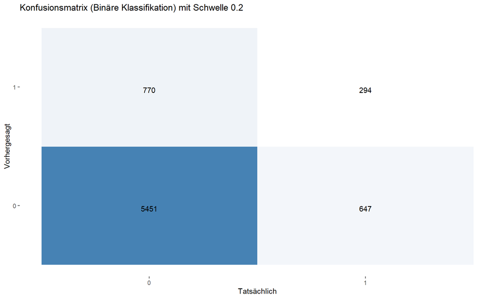

```r
cm_table <- as.data.frame(conf_mat_inter$table)

ggplot(data = cm_table, aes(x = Reference, y = Prediction)) +
  geom_tile(aes(fill = Freq), color = "white") +
  geom_text(aes(label = Freq), vjust = 1) +
  scale_fill_gradient(low = "white", high = "steelblue") +
  theme(legend.position = "none",
        panel.background = element_rect(fill = "white", color = NA),
        plot.background = element_rect(fill = "white", color = NA)) +
  labs(title = "Konfusionsmatrix (Binäre Klassifikation) mit Schwelle 0.2",
       x = "Tatsächlich", y = "Vorhergesagt")
```

## 5.3 c) Modellvergleich und Diskussion

Die Hinzunahme der Interaktionen hat die Prognosegüte nur geringfügig verbessert. Der AUC steigt von 0.6703056 auf 0.6736326

Konfusionsmatrix ohne Interaktion:

```r
conf_mat_glm$table
```

```
##           Reference
## Prediction    0    1
##          0 5484  660
##          1  737  281
```

Konfusionsmatrix mit Interaktion:

```r
conf_mat_inter$table
```

```
##           Reference
## Prediction    0    1
##          0 5451  647
##          1  770  294
```

Die Sensitivität ist von ursprünglich 0.29862 ohne Interaktion auf 0.31243 mit Interaktion gestiegen, die Spezifität von 0.88153 auf 0.87623 gesunken.

**Ansätze zur weiteren Erhöhung der Modellgüte**

- Hinzunahme von mehr Interaktionen (nicht nur drei)
- Nutzung von Interaktionen mit Polynomialen oder Splines

# 6 R5: Regularisierte Lineare Modelle und GAMs

Für die folgende Modellierung wird die Funktion *glmnet* aus dem gleichnamigen Paket verwendet. In der Funktion ist der Parameter *alpha* per default = 1 und entspricht einer *Lasso* bzw. *L1-Anpassung*. Für alpha = 0 wird eine *Ridge* bzw. *L2-Anpassung* berechnet.

## 6.1 a) L1-Regularisierung (LASSO)

Aufbereitung der Datensätze für die L1-Regularisierung:

```r
x <- model.matrix(~ ., data = train_data_glm %>% dplyr::select(-TARGET))
y <- as.numeric(train_data_glm$TARGET) - 1
```

Die Bestimmung des “optimalen” Lambda bzw. optimalen Modells erfolgt über eine Kreuzvalidierung mit Hilfe der Funktion *cv.glmnet*.

Die roten Punkte in der folgenden Grafik zeigen die Cross-Validation-Werte für den entsprechenden (log)-Lambda-Wert.

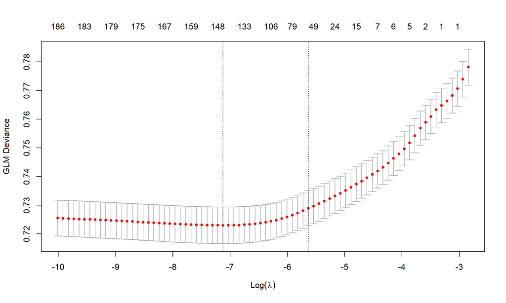

```r
cvfit_lasso <- glmnet::cv.glmnet(x, y, alpha = 1, family = binomial)
plot(cvfit_lasso)
```

**Bemerkung:** Wie im Kapitel zur Datenanalyse bereits festgestellt wurde, überwiegt die Klasse “0” in der TARGET-Variable (*y*). Auch hier wäre es möglich, in der Funktion *cv.glmnet* eine Gewichtung der einzelnen Beobachtungen mit dem Parameter *weights* mitzugeben. Dieser Schritt sollte im Zuge einer Modelloptimierung auf jeden Fall angedacht werden.

```r
print(cvfit_lasso)
```

```
##
## Call:  glmnet::cv.glmnet(x = x, y = y, alpha = 1, family = binomial)
##
## Measure: GLM Deviance
##
##       Lambda Index Measure       SE Nonzero
## min 0.000805    47  0.7230 0.006374     146
## 1se 0.003567    31  0.7288 0.006146      56
```

Der Wert *min* in der oberen Tabelle zeigt den Lambda-Wert mit dem minimalsten *Cross-Valdation-Error*, der Wert *1se* gibt den Lambda-Wert für das minimalste Modell an, für dass der *Cross-Valdation-Error* innerhalb einer Standardabweichung zum Minimun liegt. Das Modell mit dem lambda-Wert *lambda.1se* hat deutlich weniger von 0 verschiedenen Koeffizienten im Vergleich zum Modell mit lambda-Wert *lambda.min*, allerdings hat es auch einen geringeren AUC-Wert.

Im Folgenden wird das Modell für den Wert “Lambda = lambda.min” verwendet, um ein höheres Gütemaß AUC zu erhalten. Dieses Modell hat folgende von Null verschiedene Koeffizienten:

```r
Coef_lasso <- data.frame(as.matrix(coef(cvfit_lasso, s = "lambda.min"))) %>%
  tibble::rownames_to_column(var = "Merkmal") %>%
  dplyr::filter(s1 != 0)
Coef_lasso
```

```
##                                                   Merkmal           s1
## 1                                            X.Intercept. -2.721214458
## 2                                              genderMale -0.027660942
## 3                                    chlorpropamideSteady -0.949798540
## 4                                       tolbutamideSteady -0.252706052
## 5                                          miglitolSteady -0.771417912
## 6                                        tolazamideSteady -1.205193731
## 7                               glyburide.metforminSteady -0.072030706
## 8                                          diabetesMedYes  0.367340080
## 9                                       nateglinideSteady -0.047042570
## 10                                          nateglinideUp -2.333062759
## 11                                         acarboseSteady -0.334593386
## 12                                             acarboseUp -0.009597594
## 13                                      max_glu_serumNone -0.065550229
## 14                                          A1CresultNone  0.135763825
```

[output cut: 133 more lines]

Insgesamt enthält das Modell 147 Koeffizienten die nicht 0 sind.

**Zusammenhang mit der EDA aus R2**

- Die binären kategoriellen Merkmale *gender* und *change* haben eine ähnliche 50/50 Aufteilung der Ausprägungen (*Female*/*Male* bzw. *Ch*/*No*) und ein ähnliches Verhalten in der Abhängigkeit zur Zielvariable, trotzdem sind die Koeffizienten von *change* 0, die von *gender* nicht. Ein Grund könnte die hohe Korrelation von *change* mit *diabetesMed* sein, wodurch *change* nicht mehr zur Prognose der Zielvariable benötigt wird / nicht mehr signifikant ist.
- Alle Koeffizienten des Merkmals *glyburide* sind 0. Dieses Ergbnis war rein aus der EDA nicht unbedingt erwartbar, da für alle Ausprägungen ausreichend Beobachtungen vorhanden sind, und es eine - allerdings geringe - Differenz im Durchschnittswert der Zielvariable gibt. Offensichtlich sind die Differenzen zu gering, damit das Merkmal signifikant für die Prognose der Zielvariable ist.
- Alle nicht-kategoriellen Variablen haben einen nicht-null Koeffizienten.

**Berechnung des AUC auf den Testdaten**

Berechnung der Wahrscheinlichkeit für den Wert 1 in der Zielvariable für alle Beobachtungen im Test-Datensatz:

```r
xnew <- model.matrix(~ ., data = test_data_glm %>% dplyr::select(-TARGET))
probs_lasso <- predict(cvfit_lasso, newx = xnew, s = "lambda.min", type = "response")
```

Der AUC-Wert der Testdaten ist 0.6717146.

```r
MLmetrics::AUC(probs_lasso, test_data_glm$TARGET)
```

```
## [1] 0.6717146
```

**Berechnung der Konfusionsmatrix mit Schwellwert 0.2**

```r
predicted_class_lasso <- ifelse(probs_lasso >= 0.2, 1, 0)
conf_mat_lasso <- caret::confusionMatrix(factor(predicted_class_lasso), factor(test_data_glm$TARGET), positive = "1")
conf_mat_lasso$table
```

```
##           Reference
## Prediction    0    1
##          0 5543  678
##          1  678  263
```

Grafische Darstellung der Konfusionsmatrix:

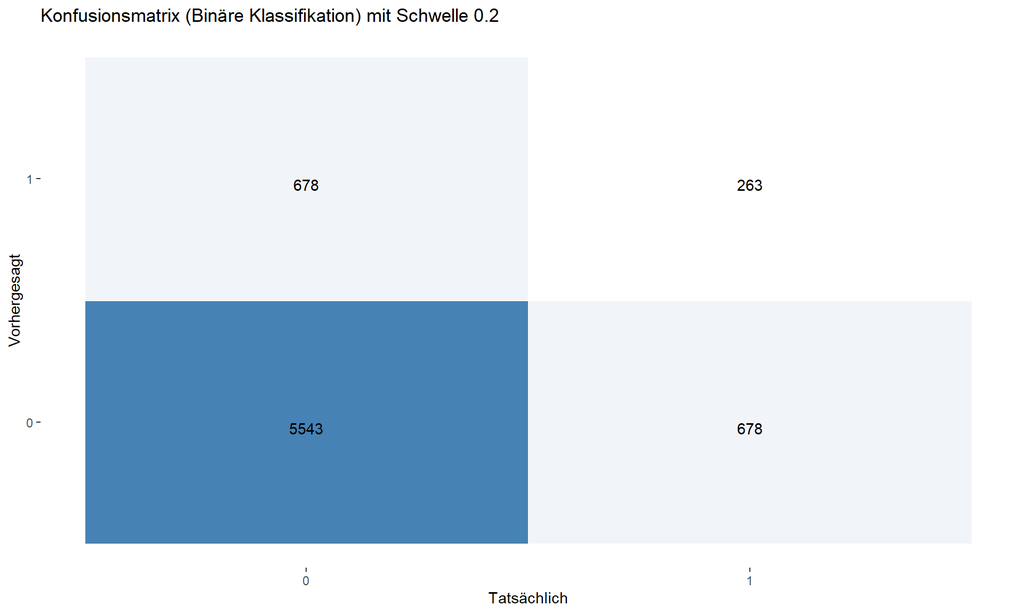

```r
cm_table <- as.data.frame(conf_mat_lasso$table)

ggplot(data = cm_table, aes(x = Reference, y = Prediction)) +
  geom_tile(aes(fill = Freq), color = "white") +
  geom_text(aes(label = Freq), vjust = 1) +
  scale_fill_gradient(low = "white", high = "steelblue") +
  theme(legend.position = "none",
        panel.background = element_rect(fill = "white", color = NA),
        plot.background = element_rect(fill = "white", color = NA)) +
  labs(title = "Konfusionsmatrix (Binäre Klassifikation) mit Schwelle 0.2",
       x = "Tatsächlich", y = "Vorhergesagt")
```

## 6.2 b) L2-Regularisierung (Ridge Regression)

Aufbereitung der Datensätze für die L2-Regularisierung (sind gleich den Daten der L1-Regulierung) und Bestimmung des “optimalen” Lambda bzw. optimalen Modells über eine Kreuzvalidierung mit Hilfe der Funktion *cv.glmnet*.

```r
x <- model.matrix(~ ., data = train_data_glm %>% dplyr::select(-TARGET))
y <- as.numeric(train_data_glm$TARGET) - 1
fit_ridge <- glmnet::glmnet(x, y, alpha = 0, family = "binomial")
```

Die roten Punkte in der folgenden Grafik zeigen die Cross-Validation-Werte für den entsprechenden (log)-Lambda-Wert.

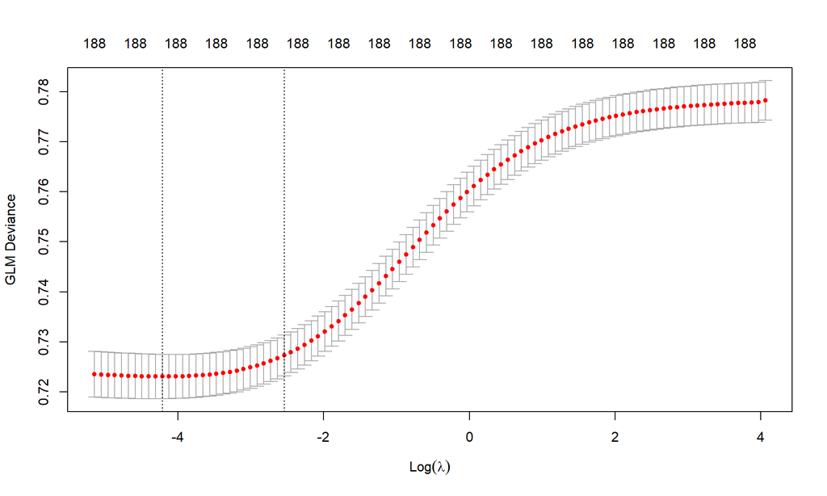

```r
cvfit_ridge <- glmnet::cv.glmnet(x, y, alpha = 0, family = binomial)
plot(cvfit_ridge)
```

Wichtige Lambda-Werte:

```r
print(cvfit_ridge)
```

```
##
## Call:  glmnet::cv.glmnet(x = x, y = y, alpha = 0, family = binomial)
##
## Measure: GLM Deviance
##
##      Lambda Index Measure       SE Nonzero
## min 0.01474    90  0.7231 0.004433     188
## 1se 0.07865    72  0.7273 0.004070     188
```

Im Folgenden wird wie im vorigen Abschnitt das Modell für den Wert “Lambda = lambda.min” verwendet. Dieses Modell hat folgende Koeffizienten:

```r
Coef_ridge <- data.frame(as.matrix(coef(cvfit_ridge, s = "lambda.min"))) %>%
  tibble::rownames_to_column(var = "Merkmal") %>%
  dplyr::filter(s1 != 0)
Coef_ridge
```

```
##                                                   Merkmal            s1
## 1                                            X.Intercept. -2.7338620609
## 2                                              genderMale -0.0400037751
## 3                                    chlorpropamideSteady -1.1653582150
## 4                                       tolbutamideSteady -0.6086150183
## 5                                          miglitolSteady -1.7133924747
## 6                                        tolazamideSteady -1.6590954650
## 7                               glyburide.metforminSteady -0.1354358365
## 8                                                changeNo -0.0152600643
## 9                                          diabetesMedYes  0.3063389596
## 10                                      nateglinideSteady -0.1234873844
## 11                                          nateglinideUp -2.5818269613
## 12                                         acarboseSteady -0.4476792860
## 13                                             acarboseUp -1.4803880804
## 14                                      max_glu_serum.300  0.0284973745
```

[output cut: 175 more lines]

Insgesamt enthält das Modell 189 Koeffizienten die nicht 0 sind (das sind alle Koeffizienten des Modells, da - im Gegensatz zum Lasso-Verfahren - kein Koeffizienten ausgeschlossen werden).

**Berechnung des AUC auf den Testdaten**

Berechnung der Wahrscheinlichkeit für den Wert 1 in der Zielvariable für alle Beobachtungen im Test-Datensatz:

```r
xnew <- model.matrix(~ ., data = test_data_glm %>% dplyr::select(-TARGET))
probs_ridge <- predict(cvfit_ridge, newx = xnew, s = "lambda.min", type = "response")
```

Der AUC-Wert der Testdaten ist 0.6713463.

```r
MLmetrics::AUC(probs_ridge, test_data_glm$TARGET)
```

```
## [1] 0.6713463
```

**Berechnung der Konfusionsmatrix mit Schwellwert 0.2**

```r
predicted_class_ridge <- ifelse(probs_ridge >= 0.2, 1, 0)
conf_mat_ridge <- caret::confusionMatrix(factor(predicted_class_ridge), factor(test_data_glm$TARGET), positive = "1")
conf_mat_ridge$table
```

```
##           Reference
## Prediction    0    1
##          0 5558  681
##          1  663  260
```

Grafische Darstellung der Konfusionsmatrix:

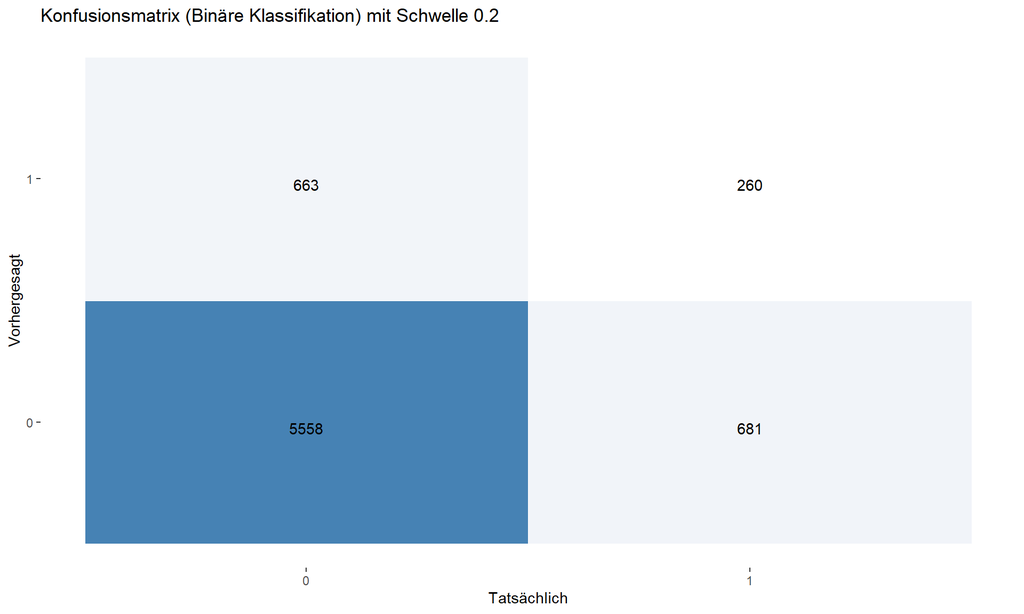

```r
cm_table <- as.data.frame(conf_mat_ridge$table)

ggplot(data = cm_table, aes(x = Reference, y = Prediction)) +
  geom_tile(aes(fill = Freq), color = "white") +
  geom_text(aes(label = Freq), vjust = 1) +
  scale_fill_gradient(low = "white", high = "steelblue") +
  theme(legend.position = "none",
        panel.background = element_rect(fill = "white", color = NA),
        plot.background = element_rect(fill = "white", color = NA)) +
  labs(title = "Konfusionsmatrix (Binäre Klassifikation) mit Schwelle 0.2",
       x = "Tatsächlich", y = "Vorhergesagt")
```

## 6.3 c) Generalisiertes Additives Modell (GAM):

Für das GAM-Modell werden folgende Merkmale berücksichtigt:

- 20 kategorielle Merkmale mit der höchsten (absoluten) Korrelation mit der Zielvariable
- Ausgewählte (bzw. im zweiten Schritt alle) numerische Merkmale
- Wenn das gefittete Modell mit den Merkmalen aus den beiden oberen Punkten nicht die geforderte Güte aufweist (also die AUC auf den Testdaten ist nicht höher als die AUC der Logistischen Regression aus Aufgabe *R4a*), könnten die in Aufgabe *R4b* ermittelten Interaktionen mit aufgenommen werden.

Zunächst werden die Trainingsdaten in eine rein numerische Matrix umgewandelt, um die Korrelationen mit der Zielvariable bestimmen zu können

```r
train_data_glm_num <- fac_to_num(train_data_glm, logistic = TRUE)
```

Die drei Diagnose-Merkmale *diag_1*, *diag_2* und *diag_3* werden von der Analyse ausgenommen, da sie nicht im Modell berücksichtigt werden.

```r
all_fac_col <- merkmale_info %>%
  dplyr::filter(Typ == "factor",
                Merkmal %in% colnames(train_data_glm_num)) %>%
  dplyr::pull(Merkmal)
all_fac_col <- all_fac_col[!(all_fac_col %in% c("diag_1", "diag_2", "diag_3", "TARGET"))]
```

Ermittlung der 20 Merkmale mit der höchsten (absoluten) Korrelation mit der Zielvariable:

```r
cor_scores_fac <- sapply(train_data_glm_num[, all_fac_col],
                         function(x) cor(x, train_data_glm_num$TARGET, method = "spearman"))
cor_scores_fac_sorted <- sort(abs(cor_scores_fac), decreasing = TRUE)
(predictors_fac <- head(cor_scores_fac_sorted, 20)  %>%
  names())
```

```
##  [1] "discharge_disposition_id" "age"
##  [3] "diabetesMed"              "weight"
##  [5] "group_diag_1"             "change"
##  [7] "repaglinide"              "payer_code"
##  [9] "admission_source_id"      "medical_specialty"
## [11] "metformin"                "race"
## [13] "glipizide"                "admission_type_id"
## [15] "insulin"                  "glyburide"
## [17] "group_diag_2"             "gender"
## [19] "A1Cresult"                "tolazamide"
```

Die Kurvenverläufe der numerischen Merkmale in Abschnitt *R3.3* - *Integer-Variablen (Gruppe 5)* zeigen, das kein lineares Verhalten zugrund liegt. Bisher wurde in allen Modellen (ausgenommen XGBoost) für die numerischen Merkmale indirekt ein linearer Verlauf verausgesetzt und nur ein Koeffizient für das gesamte Merkmal bestimmt.

In einen GAM-Modell kann mittels Ploynomen (*I(…)*) oder Splines (*s(…)*) ein Kurvenverlauf für die einzelnen Merkmale im Modell berücksichtigt werden. Im Folgenden Ansatz wird für jedes berücksichtigte numerische Merkmal ein quadratisches Polynom verwendet, da die Kurvenverläufe in Abschnitt *R3.3* für die meisten Merkmale in den Bereichen mit vielen Beobachtungen einen annähernd quadratischen Verlauf zeigen. Speziell die Verläufe der numerischen Variablen *number_inpatient*, *time_in_hospital* und *num_medications* zeigen in den kleineren Wertebereichen mit vielen Beobachtungen diesen quadratischen Zusammenhang. Bei den beiden Variablen *number_diagnoses* und *num_lab_procedures* ist der Verlauf eher linear, dennoch wird ebenfalls ein Polynom verwendet. Alle entsprechenden Grafiken sind in Abschnitt *R3.3 Claim rates for individual features* im Teil *Integer-Variablen (Gruppe 5)* zu finden und werden hier nicht nochmals dargestellt. Der Durchschnittswert der Zielvariable pro Ausprägung ist mit einem gelben Punkt markiert und damit der Verlauf deutlich erkennbar.

**Bemerkung**: Möglich wäre auch die Verwendung eines Splines, beispielsweise in der Form *s(Merkmal, k = 3)*. In diesem Fall wird für das Merkmal ein Verlauf mit drei Basisfunktionen aufgebaut.

Die oben erwähnten fünf numerischen Merkmale werden im GAM-Modell berücksichtigt.

```r
predictors_int <- c("number_inpatient", "time_in_hospital", "num_medications", "number_diagnoses", "num_lab_procedures")
```

Erstellung der benötigten Formel und Berechnung des Modells.

```r
formula_str <- paste("TARGET ~", paste(c(sprintf("%s + I(%s^2)", predictors_int, predictors_int), sprintf("%s", predictors_fac)), collapse = " + "))
gam_formula <- as.formula(formula_str)
gam_model_5num <- mgcv::gam(gam_formula, method = "REML", data = train_data_glm, family = binomial)
```

**Berechnung des AUC auf den Testdaten**

Berechnung der Wahrscheinlichkeit für den Wert 1 in der Zielvariable für alle Beobachtungen im Test-Datensatz:

```r
probs_gam_5num <- predict(gam_model_5num, newdata = test_data_glm, type = "response")
```

Der AUC-Wert der Testdaten ist 0.6720808.

```r
MLmetrics::AUC(probs_gam_5num, test_data_glm$TARGET)
```

```
## [1] 0.6720808
```

Vergleich mit AUC der Logistischen Regression:

```r
MLmetrics::AUC(probs_glm, test_data_glm$TARGET)
```

```
## [1] 0.6703056
```

Das oben konstruierte GAM-Modell mit 20 kategoriellen Merkmalen und einen quadratischen Verlauf für alle fünf verwendeten numerischen Merkmale liefert mit 0.6720808 einen höheren AUC-Wert auf den Testdaten als das zu vergleichende Logistische Modell (AUC-Wert 0.6703056). Damit entfallen weitere Maßnahmen zur Verbesserung des Modell, wie beispielsweise die Hinzunahme von Interaktionen.

Allerdins werden in einem zweiten Modell alle numerischen Merkmale berücksicht, um das Gütemaß nochmals zu erhöhen. Dieses zweite Modell wird in weiterer Folge verwendet.

Ermittlung der Spaltennamen der numerischen Merkmale.

```r
predictors_int <- merkmale_info %>%
  dplyr::filter(Merkmal %in% colnames(train_data_glm_num),
                Typ == "integer") %>%
  dplyr::pull(Merkmal)
```

Erstellung der benötigten Formel und Berechnung des Modells.

```r
formula_str <- paste("TARGET ~", paste(c(sprintf("%s + I(%s^2)", predictors_int, predictors_int), sprintf("%s", predictors_fac)), collapse = " + "))
gam_formula <- as.formula(formula_str)
gam_model <- mgcv::gam(gam_formula, method = "REML", data = train_data_glm, family = binomial)
```

**Berechnung des AUC auf den Testdaten**

Berechnung der Wahrscheinlichkeit für den Wert 1 in der Zielvariable für alle Beobachtungen im Test-Datensatz:

```r
probs_gam <- predict(gam_model, newdata = test_data_glm, type = "response")
```

Der AUC-Wert der Testdaten ist 0.6746107.

```r
MLmetrics::AUC(probs_gam, test_data_glm$TARGET)
```

```
## [1] 0.6746107
```

Vergleich mit AUC der Logistischen Regression:

```r
MLmetrics::AUC(probs_glm, test_data_glm$TARGET)
```

```
## [1] 0.6703056
```

Das GAM-Modell mit 20 kategoriellen Merkmalen und einen quadratischen Verlauf für alle numerischen Merkmale liefert mit 0.6746107 einen höheren AUC-Wert auf den Testdaten als das zu vergleichende Logistische Modell (AUC-Wert 0.6703056) bzw. das GAM-Modell mit fünf numerischen Merkmalen (AUC-Wert 0.6720808).

**Berechnung der Konfusionsmatrix mit Schwellwert 0.2**

```r
predicted_class_gam <- ifelse(probs_gam >= 0.2, 1, 0)
conf_mat <- caret::confusionMatrix(factor(predicted_class_gam), factor(test_data_glm$TARGET), positive = "1")
conf_mat$table
```

```
##           Reference
## Prediction    0    1
##          0 5461  640
##          1  760  301
```

Grafische Darstellung der Konfusionsmatrix:

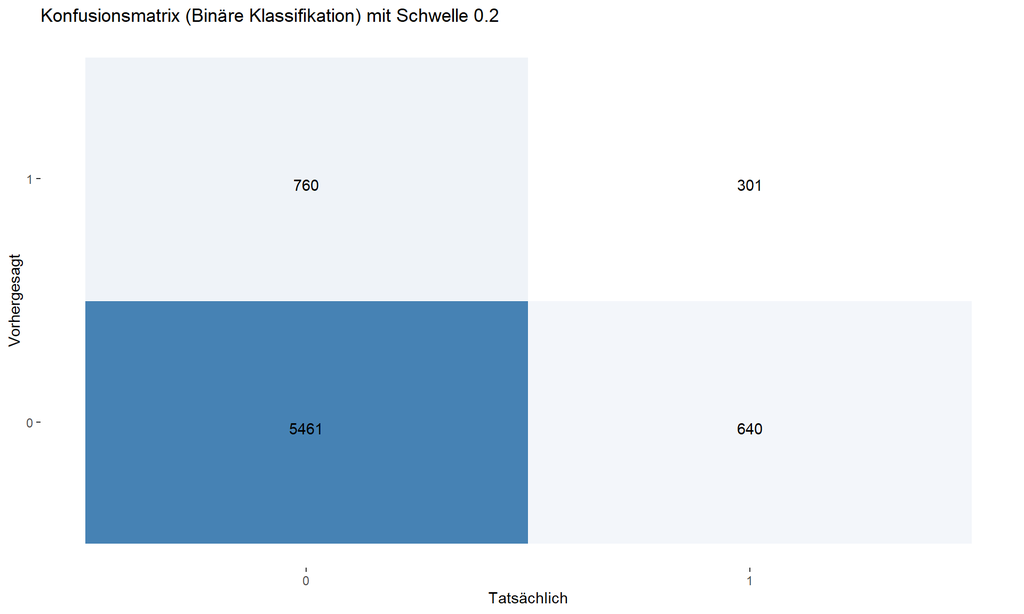

```r
cm_table <- as.data.frame(conf_mat$table)

ggplot(data = cm_table, aes(x = Reference, y = Prediction)) +
  geom_tile(aes(fill = Freq), color = "white") +
  geom_text(aes(label = Freq), vjust = 1) +
  scale_fill_gradient(low = "white", high = "steelblue") +
  theme(legend.position = "none",
        panel.background = element_rect(fill = "white", color = NA),
        plot.background = element_rect(fill = "white", color = NA)) +
  labs(title = "Konfusionsmatrix (Binäre Klassifikation) mit Schwelle 0.2",
       x = "Tatsächlich", y = "Vorhergesagt")
```

## 6.4 d) Vergleich und Diskussion

Alle Modelle haben ähnlich hohe AUC-Werte, insofern kann dieses Gütemaß nicht für die Entscheidung herangezogen werden.

- Logistische Regressionen ohne Interaktionen: 0.6703056
- Logistische Regression mit Interaktionen: 0.6736326
- L1-Regularisierung (LASSO): 0.6717146
- L2-Regularisierung (Ridge Regression): 0.6713463
- Generalisiertes Additives Modell (GAM): 0.6746107

Die Modelle dienen dazu, ein seltenes Ereignis (frühzeitige Wiedereinweisung innerhalb von 30 Tagen) zu prognostizieren. Wichtig für eine präventive Vorsorge ist, die Wiedereinweisungen mit hoher Wahrscheinlichkeit richtig zu erkennen. Die Maßzahl *Sensitivität* (True Positive Rate) misst, wie viele Wiedereinweisungen richtig erkannt wurden. Ein Modell mit hoher Sensitivität ist somit geeignet, wesentlichen Treiber für die Wiedereinweisung zu erkennen und damit die Behandlungsansätze bzw. -qualität zu verbessern. Deshalb werden im folgenden die Sensitivitäten der einzelnem Modelle verglichen.

**Bemerkung**: Die Spezifität misst, wie viele Nicht-Wiedereinweisungen richtig prognostiziert wurden. Ein Modell mit hoher Spezifität, aber niedriger Sensitivität würde somit viele Wiedereinweisungen übersehen und deshalb auch nicht geeignet sein, Treiber für die Wiedereinweisung zu finden.

Die Sensitivitäten der fünf betrachteten Modelle werden abhängig von verschiedenen Schwellwerten ermittelt und übersichtlich in einer Tabelle zusammengestellt:

```r
probs_list <- list()
probs_list$glm <- show_sensi(probs_glm)
probs_list$inter <- show_sensi(probs_inter)
probs_list$lasso <- show_sensi(probs_lasso)
probs_list$ridge <- show_sensi(as.vector(probs_ridge))
probs_list$gam <- show_sensi(probs_gam)

name_list <- names(probs_list)

tmp <- purrr::imap(probs_list, ~ {
  df <- .x
  df <- df[, 1:2]  # Nur erste und zweite Spalte
  names(df)[2] <- .y  # Spaltenname umbenennen zur Listennamen
  df
})

(vergleich <- purrr::reduce(tmp, dplyr::full_join, by = names(tmp[[1]])[1]))
```

```
##    Schwelle         glm       inter       lasso       ridge         gam
## 1      0.05 0.962805526 0.959617428 0.978746015 0.980871413 0.963868225
## 2      0.10 0.747077577 0.741764081 0.761955367 0.769394261 0.747077577
## 3      0.15 0.476089267 0.488841658 0.448459086 0.458023379 0.480340064
## 4      0.20 0.298618491 0.312433581 0.279489904 0.276301807 0.319872476
## 5      0.25 0.213602550 0.218916047 0.193411265 0.191285866 0.215727949
## 6      0.30 0.153028693 0.161530287 0.141339001 0.137088204 0.148777896
## 7      0.35 0.119022317 0.128586610 0.104144527 0.098831031 0.120085016
## 8      0.40 0.091392136 0.091392136 0.073326249 0.068012752 0.093517535
## 9      0.45 0.060573858 0.069075452 0.048884166 0.046758767 0.058448459
## 10     0.50 0.043570670 0.047821467 0.037194474 0.035069075 0.042507970
## 11     0.55 0.035069075 0.035069075 0.029755579 0.027630181 0.032943677
## 12     0.60 0.025504782 0.023379384 0.019128587 0.015940489 0.023379384
## 13     0.65 0.017003188 0.017003188 0.012752391 0.011689692 0.015940489
## 14     0.70 0.012752391 0.010626993 0.010626993 0.007438895 0.012752391
## 15     0.75 0.008501594 0.009564293 0.006376196 0.006376196 0.008501594
## 16     0.80 0.005313496 0.005313496 0.005313496 0.004250797 0.005313496
## 17     0.85 0.004250797 0.004250797 0.004250797 0.003188098 0.001062699
## 18     0.90 0.003188098 0.004250797 0.003188098 0.003188098 0.000000000
## 19     0.95 0.002125399 0.002125399 0.001062699 0.000000000 0.000000000
```

Auch der Vergleich der Sensitivitäten bringt kein eindeutig bestes Modell. Sowohl beim Vergleich der AUC-Werte, als auch beim Vergleich der Sensitivitäten (beispielsweise mit Schwelle 0.2), schneiden die “Logistische Regression mit Interaktionen” und das “Generalisiertes Additives Modell (GAM)” am Besten ab. Aufgrund der besseren Erklärbarkeit der einzelnen Regressionskoeffizienten würde meine Wahl auf die *Logistische Regression mit Interaktionen* fallen.

# 7 R6: Ternäre Klassifikation

## 7.1 a) Evaluationsmetriken bei binärer und ternärer Klassifikation

Die *AUC* (Area Under the Curve, speziell ROC-AUC) misst die Fläche unter der ROC-Kurve – also die Trade-off-Beziehung zwischen Sensitivität (True Positive Rate) und 1 - Spezifität (False Positive Rate).

**Vorteile von AUC im Vergleich zur Accuracy**

- AUC ist unabhängig vom betrachteten Schwellwert, während Accuracy einen festen Schwellwert / Cutoff bewertet.
- AUC berücksichtigt den Trade-off zwischen Sensitivität und Spezifität und gibt ein umfassenderes Bild über die Klassifikationsleistung des Modells
- Die Bewertung von AUC ist unabhängig von der Klassenverteilung, während Accuracy speziell bei unbalancierten Daten stark verzerren kann. So kann beispielsweise in diesem Fall ein Modell, dass immer nur die häufigste Klasse prognostiziert, eine hohe Accuracy haben.

**Nachteile von AUC im Vergleich zur Accuracy**

- AUC gibt keine Informationen über die Anzahl von Fehlklassifikationen bei einem bestimmten Schwellenwert, während Accuracy diesen Wert direkt zeigt.
- AUC ist im Allgemeinen schwerer interpretierbar bzw. weniger intuitiv als Accuracy.
- AUC kann bei unbalancierten Daten ebenfalls irreführend sein, da selbst bei einem hohen AUC viele “False Negativ”-Prognosen möglich sind.

**Besonderheiten bei Mehrklassen-Klassifikation**

Wie bei binärer Klassifikation, kann die Modellbewertung bei einem Datensatz mit einer dominierenden Klasse problematisch und schwierig sein. Deshalb ist es bei einer Mehrklassen-Klassifikation wichtig, auch auf die Bewertung der einzelnen Klassen zu achten und nicht nur eine Gesamtbewertung heranzuziehen.

**Evaluationsmetriken für Mehrklassen-Klassifikation**

- *Accuracy*: Anteil aller korrekt klassifizierter Beobachtungen - diese Metrik ist vor allem bei ausgeglichener Klassenverteilung sinnvoll.
- *Balanced Accuracy*: Für eine binäre Klassifikation ist die Balanced Accuracy als Mittelwert der Sensitivität und Spezifität definiert. Für eine Mehrklassen-Klassifikation ist die Balanced Accuracy der Durchschnitt der Einzel-Accuracy (= Sensitivität) pro Klasse, wobei jede Klasse gleich stark gewichtet wird (unabhängig davon, wie häufig die Klasse in den Beobachtungen vorkommt). Da die Balanced Accuracy jede Klasse gleich stark gewichtet, ist sie hervorragend für unbalancierte Beobachtungen geeignet.
- *Makro-F1-Score*: Durchschnitt der F1-Scores der einzelnen Klassen, wobei jede Klasse gleich stark gewichtet wird. Der F1-Score einer Klasse ist definiert als das harmonische Mittel aus Precision und Recall für diese Klasse. Nachdem jede Klasse gleich stark gewichtet wird, ist diese Metrik ebenfalls hervorragend für unbalancierte Beobachtungen geeignet.

**Bemerkung**:

- Die *Precision* gibt an, wie viele als positiv prognostizierte Beobachtungen tatsächlich positiv waren, d.h. Precision = TP / (TP + FP)
- Der *Recall* gibt an, welcher Anteil von tatsächlich positiven Beobachtungen vom Modell erkannt wurden d.h. Recall = TP / (TP + FN)

Die folgende Funktion *evaluate_multiclass* berechnet die oben beschriebenen Metriken *Accuracy*, *Balanced Accuracy* und *Makro-F1-Score*:

```r
evaluate_multiclass <- function(predicted_class, true_class) {
  conf_mat <- caret::confusionMatrix(predicted_class, true_class)

  # Accuracy
  accuracy <- as.numeric(conf_mat$overall["Accuracy"])

  # Balanced Accuracy => Durchschnitt der Einzel-Accuracy (= Sensitivität) pro Klasse
  balanced_accuracy <- conf_mat$byClass[, "Sensitivity"]
  balanced_accuracy <- mean(balanced_accuracy, na.rm = TRUE)

  predicted_class_int <- as.integer(predicted_class)
  true_class_int <- as.integer(true_class)

  # Macro-F1
  cm <- conf_mat$table
  precision <- diag(cm) / rowSums(cm)
  recall <- diag(cm) / colSums(cm)
  f1 <- 2 * precision * recall / (precision + recall)
  macro_f1 <- sum(f1, na.rm = TRUE) / length(f1)

  # Rückgabe
  result <- list()
  result$Accuracy <- accuracy
  result$Balanced_Accuracy <- balanced_accuracy
  result$Macro_F1 <- macro_f1

  return(result)
}
```

## 7.2 b) Ternäre Klassifikation mit Multinomialer Logistischer Regression

Für die nachfolgende Modellierung werden nur jene Merkmale verwendet, die zumindest zwei Ausprägungen haben. Weiters werden die Merkmale *diag_1*, *diag_2* und *diag_3* wie vorgegeben nicht im Modell berücksichtig. In den vorigen Abschnitten wurden die Namen der zu berücksichtigenden Merkmale bereits ermittelt und in der Variable *keep_col* gespeichert.

```r
train_data_multi <- train_data_ter[,keep_col]
test_data_multi <- test_data_ter[,keep_col]
```

Training des Modells mit der Funktion *multinom* (die Anzahl der maximalen Iterationen wurde auf 500 erhöht):

```r
multilog_model <- nnet::multinom(TARGET ~ ., data = train_data_multi, family = binomial, maxit = 500)
```

Schätzung der Wahrscheinlichkeit pro Klasse für die Beobachtungen des Testdatensatz:

```r
probs_multinom <- predict(multilog_model, newdata = test_data_multi, type = "probs")
```

Die folgende Funktion *probs_predict* dient zur Optimierung der Klassenschwellen, um die Verteilung der Prognosen an die tatsächliche Verteilung der TARGET-Variable anzunähern. Die Idee für die Optimierung ist, einen Schwellwert für die erste und zweite Klasse vorzugeben. Liegt die prognostizierte Wahrscheinlichkeit für die erste Klasse über dem ersten Schwellwert, so ist die Prognose die “Klasse 1”. Ist dies nicht der Fall, wird geprüft, ob die prognostizierte Wahrscheinlichkeit für die zweite Klasse über dem zweiten Schwellwert liegt. Ist das der Fall, so ist die Prognose “Klasse 2”, andernfalls “Klasse 3”.

```r
probs_predict <- function(probs, p1, p2) {
  probs[,1] <- (probs[,1] >= p1)
  probs[,2] <- ((probs[,1] < p1) & (probs[,2] >= p2))
  probs[,3] <- 1 - probs[,1] - probs[,2] # (probs[,1] < p1) & (probs[,2] < 0.5)

  if (sum(probs) != nrow(probs)) {
    print("Problem")
  }

  pred <- as.integer(max.col(probs))
  pred <- factor(pred, levels = 1:length(levels(test_data_multi$TARGET)), labels = levels(test_data_multi$TARGET))
  return(pred)
}
```

Die Optimierung der Klassenschwellwerte erfolgt mit einer Schrittweite von 0.05 für beide Schwellwerte.

```r
uebersicht <- NULL
for (p1 in seq(0, 0.95, 0.05)) {
  for (p2 in seq(0, 0.95, 0.05)) {
    probs <- probs_multinom

    pred <- probs_predict(probs, p1, p2)
    tmp <- evaluate_multiclass(pred, test_data_multi$TARGET)

    tmp_df <- data.frame(p1 = p1,
                         p2 = p2,
                         Accuracy = tmp$Accuracy,
                         Balanced_Accuracy = tmp$Balanced_Accuracy,
                         Macro_F1 = tmp$Macro_F1)

    uebersicht <- rbind(uebersicht, tmp_df)
  }
}
```

**Analyse für die Metrik “Accuracy”**

Für die Berechnung der endgültigen Prognose werden jene Schwellwerte verwendet, für die die Metrik *Accuracy* maximiert wird. Die folgende Tabelle zeigt eine Übersicht über die 10 Schwellwerte mit den höchsten Werten für diese Metrik.

```r
best_multinom_acc <- uebersicht %>%
  dplyr::arrange(desc(Accuracy)) %>%
  head(10)
best_multinom_acc
```

```
##      p1   p2  Accuracy Balanced_Accuracy  Macro_F1
## 1  0.50 0.45 0.6090519         0.3703238 0.3373300
## 2  0.55 0.45 0.6089566         0.3697153 0.3359873
## 3  0.35 0.45 0.6088614         0.3769923 0.3518668
## 4  0.40 0.45 0.6088614         0.3733845 0.3443194
## 5  0.45 0.45 0.6087661         0.3709722 0.3391092
## 6  0.30 0.45 0.6086708         0.3854404 0.3676781
## 7  0.60 0.45 0.6086708         0.3686527 0.3337932
## 8  0.65 0.45 0.6086708         0.3686527 0.3337932
## 9  0.70 0.45 0.6086708         0.3686527 0.3337932
## 10 0.75 0.45 0.6086708         0.3686527 0.3337932
```

Prognose der Testdaten und Berechnung der Konfusionsmatrix:

```r
pred_multinom_acc <- probs_predict(probs_multinom, p1 = best_multinom_acc$p1[1], p2 = best_multinom_acc$p2[1])
conf_mat_multinom_acc <- caret::confusionMatrix(pred_multinom_acc, test_data_multi$TARGET)
conf_mat_multinom_acc$table
```

```
##           Reference
## Prediction  <30  >30   NO
##        <30    5    6    0
##        >30  157  567  401
##        NO   779 2760 5820
```

Grafische Darstellung der Konfusionsmatrix:

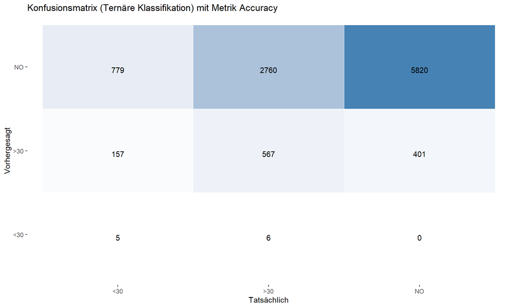

```r
cm_table <- as.data.frame(conf_mat_multinom_acc$table)

ggplot(data = cm_table, aes(x = Reference, y = Prediction)) +
  geom_tile(aes(fill = Freq), color = "white") +
  geom_text(aes(label = Freq), vjust = 1) +
  scale_fill_gradient(low = "white", high = "steelblue") +
  theme(legend.position = "none",
        panel.background = element_rect(fill = "white", color = NA),
        plot.background = element_rect(fill = "white", color = NA)) +
  labs(title = "Konfusionsmatrix (Ternäre Klassifikation) mit Metrik Accuracy",
       x = "Tatsächlich", y = "Vorhergesagt")
```

Die Klasse “No” ist die dominierende Klasse der Zielvariable. Typischerweise für unbalancierten Beobachtungen, wird in der Metik *Accuracy* die dominierende Klasse bevorzugt bzw. überschätzt (siehe z.B. die Anzahl für vorhergesagt “No” und tatsächlich “>30”).

**Analyse für die Metrik “Balanced Accuracy”**

Für die Berechnung der endgültigen Prognose werden jene Schwellwerte verwendet, für die die Metrik *Balanced Accuracy* maximiert wird. Die folgende Tabelle zeigt eine Übersicht über die 10 Schwellwerte mit den höchsten Werten für diese Metrik.

```r
best_multinom_balacc <- uebersicht %>%
  dplyr::arrange(desc(Balanced_Accuracy)) %>%
  head(10)
best_multinom_balacc
```

```
##      p1   p2  Accuracy Balanced_Accuracy  Macro_F1
## 1  0.15 0.30 0.5064316         0.4372767 0.4219763
## 2  0.15 0.35 0.5534064         0.4371358 0.4345656
## 3  0.10 0.35 0.4760362         0.4366652 0.3948403
## 4  0.10 0.30 0.4375417         0.4363285 0.3880561
## 5  0.20 0.30 0.5254883         0.4327159 0.4226445
## 6  0.20 0.35 0.5741782         0.4315431 0.4366417
## 7  0.25 0.30 0.5305384         0.4249514 0.4115917
## 8  0.10 0.40 0.4907099         0.4245349 0.3704849
## 9  0.25 0.35 0.5799905         0.4237894 0.4263382
## 10 0.10 0.25 0.3811339         0.4232721 0.3506055
```

Prognose der Testdaten und Berechnung der Konfusionsmatrix:

```r
pred_multinom_balacc <- probs_predict(probs_multinom, p1 = best_multinom_balacc$p1[1], p2 = best_multinom_balacc$p2[1])
conf_mat_multinom_balacc <- caret::confusionMatrix(pred_multinom_balacc, test_data_multi$TARGET)
conf_mat_multinom_balacc$table
```

```
##           Reference
## Prediction  <30  >30   NO
##        <30  209  419  483
##        >30  446 1931 2563
##        NO   286  983 3175
```

Grafische Darstellung der Konfusionsmatrix:

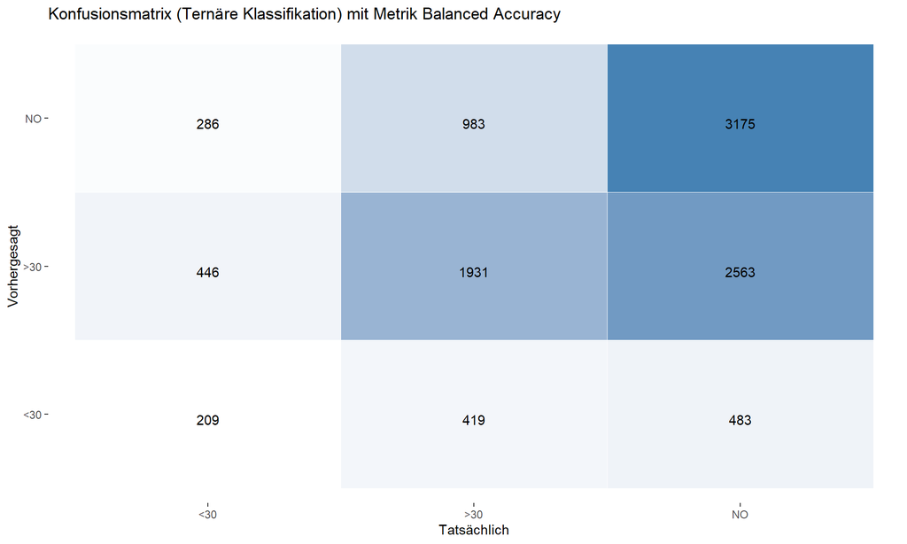

```r
cm_table <- as.data.frame(conf_mat_multinom_balacc$table)

ggplot(data = cm_table, aes(x = Reference, y = Prediction)) +
  geom_tile(aes(fill = Freq), color = "white") +
  geom_text(aes(label = Freq), vjust = 1) +
  scale_fill_gradient(low = "white", high = "steelblue") +
  theme(legend.position = "none",
        panel.background = element_rect(fill = "white", color = NA),
        plot.background = element_rect(fill = "white", color = NA)) +
  labs(title = "Konfusionsmatrix (Ternäre Klassifikation) mit Metrik Balanced Accuracy",
       x = "Tatsächlich", y = "Vorhergesagt")
```

Die Konfusionsmatrix zeigt, dass insgesamt weniger Prognosen im Vergleich zur Metrik *Accuracy* korrekt sind, allerdings die beiden kleineren aber wichtigeren Klassen “<30” und “>30” deutlich öfters richtig prognostiziert wurde.

**Analyse für die Metrik “Macro-F1-Score”**

Für die Berechnung der endgültigen Prognose werden jene Schwellwerte verwendet, für die die Metrik *Macro-F1-Score* maximiert wird. Die folgende Tabelle zeigt eine Übersicht über die 10 Schwellwerte mit den höchsten Werten für diese Metrik.

```r
best_multinom_macf1 <- uebersicht %>%
  dplyr::arrange(desc(Macro_F1)) %>%
  head(10)
best_multinom_macf1
```

```
##      p1   p2  Accuracy Balanced_Accuracy  Macro_F1
## 1  0.20 0.35 0.5741782         0.4315431 0.4366417
## 2  0.15 0.35 0.5534064         0.4371358 0.4345656
## 3  0.25 0.35 0.5799905         0.4237894 0.4263382
## 4  0.20 0.30 0.5254883         0.4327159 0.4226445
## 5  0.15 0.30 0.5064316         0.4372767 0.4219763
## 6  0.30 0.35 0.5840877         0.4194836 0.4183139
## 7  0.20 0.40 0.5939019         0.4144527 0.4161250
## 8  0.15 0.40 0.5721772         0.4214596 0.4128207
## 9  0.25 0.30 0.5305384         0.4249514 0.4115917
## 10 0.25 0.40 0.6000000         0.4063026 0.4065038
```

Prognose der Testdaten und Berechnung der Konfusionsmatrix:

```r
pred_multinom_macf1 <- probs_predict(probs_multinom, p1 = best_multinom_macf1$p1[1], p2 = best_multinom_macf1$p2[1])
conf_mat_multinom_macf1 <- caret::confusionMatrix(pred_multinom_macf1, test_data_multi$TARGET)
conf_mat_multinom_macf1$table
```

```
##           Reference
## Prediction  <30  >30   NO
##        <30  129  184  195
##        >30  347 1505 1634
##        NO   465 1644 4392
```

Grafische Darstellung der Konfusionsmatrix:

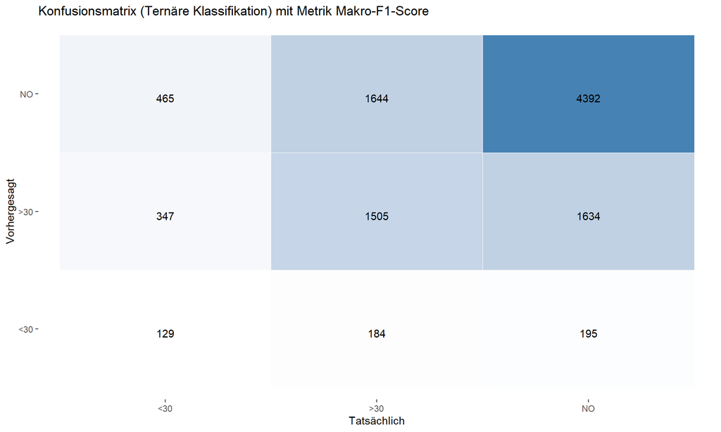

```r
cm_table <- as.data.frame(conf_mat_multinom_macf1$table)

ggplot(data = cm_table, aes(x = Reference, y = Prediction)) +
  geom_tile(aes(fill = Freq), color = "white") +
  geom_text(aes(label = Freq), vjust = 1) +
  scale_fill_gradient(low = "white", high = "steelblue") +
  theme(legend.position = "none",
        panel.background = element_rect(fill = "white", color = NA),
        plot.background = element_rect(fill = "white", color = NA)) +
  labs(title = "Konfusionsmatrix (Ternäre Klassifikation) mit Metrik Makro-F1-Score",
       x = "Tatsächlich", y = "Vorhergesagt")
```

Die Konfusionsmatrix zeigt, dass im Vergleich zur Metrik *Accuracy* weniger Prognosen korrekt sind, allerdings die beiden kleineren aber wichtigeren Klassen “<30” und “>30” häufiger richtig prognostiziert wurden. Im Vergleich zu *Balanced Accuracy* sind die kleineren Klassen nicht so häufig korrekt.

## 7.3 c) Ternäre Klassifikation mit XGBoost

Wie im Aufgabe *R3* werden zunächst die Daten für den XGBoost-Algorithmus vorbereitet.

```r
train_data_ter_num <- fac_to_num(train_data_ter, logistic = TRUE)
val_data_ter_num <- fac_to_num(val_data_ter, logistic = TRUE)
test_data_ter_num <- fac_to_num(test_data_ter, logistic = TRUE)

dtrain_ter <- xgboost::xgb.DMatrix(as.matrix(train_data_ter_num %>% dplyr::select(-TARGET)),label = train_data_ter_num$TARGET)
dvalid_ter <- xgboost::xgb.DMatrix(as.matrix(val_data_ter_num %>% dplyr::select(-TARGET)),label = val_data_ter_num$TARGET)
dtest_ter <- xgboost::xgb.DMatrix(as.matrix(test_data_ter_num %>% dplyr::select(-TARGET)))
```

**Bemerkungen**:

- Aus der Aufgabenstellung war nicht klar, welche der drei betrachteten Metriken beim Training als Loss-Funktion verwendet werden soll (bzw. ob drei verschiedene Modelle mit jeweils einer anderen Metrik zu erstellen sind). Im Folgenden werden für alle drei Metriken die entsprechenden Loss-Funktionen definiert, für das zur Analyse verwendete Modell wird *Balanced Accuracy* verwendet, da für dieses Modell die häufigsten richtigen Prognosen für die beiden kleineren Klassen “<30” und “>30” erwartet werden - siehe vorigen Abschnitt.
- Für die Analyse der Modell mit Loss-Funktion *Accuracy* bzw. *Makro-F1-Score* können dieselben Formeln wie für die verwendete *Balanced Accuracy* werden, in der Liste *xgb_ter_params* muss lediglich die entsprechende Funktion im Parameter *eval_metric* eingetragen werden.
- Wie in den Definitionen der Loss-Funktion ersichtlich, wird als Prognosewert für eine Beobachtung die Ausprägung mit der höchsten Wahrscheinlichkeit genommen (“pred_labels <- max.col(matrix(preds, ncol = 3, byrow = TRUE)) - 1”). Im Sinne der geforderten Optimierung der Klassenschwellwerte müsste eigentlich für jede Schwanke *p1* und *p2* mit der oben definierten Funktion *probs_predict* ein eigenes Modell für diese Schranken berechnet werden. Das würde allerdings einen erheblich erhöhten Rechenaufwand bedeuten. Im unten gewählten Vorgehen wird nur ein Modell mit der Schätzung anhand der höchsten Wahrscheinlichkeit pro Ausprägung entwickelt, und mit diesem Modell die Klassenschwellwerte optimiert.

**Loss-Funktion für die Metrik “Accuracy”**

```r
xgb_accuracy <- function(preds, dtrain) {
  labels <- xgboost::getinfo(dtrain, "label")
  pred_labels <- max.col(matrix(preds, ncol = 3, byrow = TRUE)) - 1

  cm <- table(factor(pred_labels, levels = 0:2), factor(labels, levels = 0:2))

  accuracy <- sum(diag(cm)) / sum(cm)

  list(metric = "accuracy", value = accuracy)
}
```

**Loss-Funktion für die Metrik “Balanced Accuracy”**

```r
xgb_balanced_accuracy <- function(preds, dtrain) {
  labels <- getinfo(dtrain, "label")
  pred_labels <- max.col(matrix(preds, ncol = 3, byrow = TRUE)) - 1

  # Confusion matrix
  cm <- table(factor(pred_labels, levels = 1:3), factor(labels, levels = 1:3))
  sensitivity <- diag(cm) / colSums(cm)
  balanced_acc <- mean(sensitivity, na.rm = TRUE)

  list(metric = "balanced_accuracy", value = balanced_acc)
}
```

**Loss-Funktion für die Metrik “Makro-F1-Score”**

```r
xgb_macro_f1 <- function(preds, dtrain) {
  labels <- xgboost::getinfo(dtrain, "label")
  pred_labels <- max.col(matrix(preds, ncol = 3, byrow = TRUE)) - 1

  cm <- table(factor(pred_labels, levels = 0:2), factor(labels, levels = 0:2))

  precision <- diag(cm) / rowSums(cm)
  recall <- diag(cm) / colSums(cm)
  f1 <- 2 * precision * recall / (precision + recall)
  macro_f1 <- sum(f1, na.rm = TRUE) / length(f1)

  list(metric = "macro_f1", value = macro_f1)
}
```

Parameter für den XGBoost-Algorithmus. Die Anzahl der zu schätzenden Klassen muss als Paramater *nun_class* angegeben werden.

```r
xgb_ter_params <- list(
  colsample_bytree = 1,
  subsample = 1,
  booster = "gbtree",
  max_depth = 5,
  eta = 0.3,
  eval_metric = xgb_balanced_accuracy,
  objective = "multi:softprob",
  num_class = 3, # Anzahl der zu schätzenden Klassen
  nthread = 1
)
```

Bestimmug der optimalen Baumtiefe durch Cross-Validation

```r
watchlist <- list(train = dtrain_ter, valid = dvalid_ter)

set.seed(1234)
xgb_ter_cv <- xgboost::xgb.cv(xgb_ter_params,
                              dtrain_ter,
                              early_stopping_rounds = 5,
                              nfold = 5,
                              print_every_n = 5,
                              nrounds = 500,
                              maximize = TRUE)
```

[output not shown]

Auslese der optimalen Baumtiefe (97), die für das Modell-Training verwendet wird.

```r
best_nrounds <- xgb_ter_cv$best_iteration

set.seed(1234)
xgb_ter_model <- xgboost::xgb.train(params = xgb_ter_params,
                                    data = dtrain_ter,
                                    print_every_n = 5,
                                    watchlist = watchlist,
                                    nrounds = best_nrounds,
                                    maximize = TRUE)
```

Schätzung der Wahrscheinlichkeit pro Klasse: die geschätzten Werte werden im XGBoost-Predictor als Vektor zurückgegeben. Dieser muss für die spätere Verwendung in eine Matrix umgewandelt werden.

```r
probs_xgb_ter <- predict(xgb_ter_model, newdata = dtest_ter)
num_class <- 3  # Anzahl deiner Klassen
probs_xgb_ter <- matrix(probs_xgb_ter, ncol = num_class, byrow = TRUE)
colnames(probs_xgb_ter) <- levels(test_data_ter$TARGET)
```

Die Optimierung der Klassenschwellwerte erfolgt mit einer Schrittweite von 0.05 für beide Schwellwerte.

```r
uebersicht <- NULL
for (p1 in seq(0, 0.95, 0.05)) {
  for (p2 in seq(0, 0.95, 0.05)) {
    probs <- probs_xgb_ter

    pred <- probs_predict(probs, p1, p2)
    tmp <- evaluate_multiclass(pred, test_data_multi$TARGET)

    tmp_df <- data.frame(p1 = p1,
                         p2 = p2,
                         Accuracy = tmp$Accuracy,
                         Balanced_Accuracy = tmp$Balanced_Accuracy,
                         Macro_F1 = tmp$Macro_F1)


    uebersicht <- rbind(uebersicht, tmp_df)
  }
}
```

**Analyse für die Metrik “Accuracy”**

Für die Berechnung der endgültigen Prognose werden jene Schwellwerte verwendet, für die die Metrik *Accuracy* maximiert wird. Die folgende Tabelle zeigt eine Übersicht über die 10 Schwellwerte mit den höchsten Werten für diese Metrik.

```r
best_xgb_ter_acc <- uebersicht %>%
  dplyr::arrange(desc(Accuracy)) %>%
  head(10)
best_xgb_ter_acc
```

```
##      p1   p2  Accuracy Balanced_Accuracy  Macro_F1
## 1  0.40 0.45 0.6123869         0.3856231 0.3663446
## 2  0.30 0.45 0.6121963         0.3961537 0.3866799
## 3  0.45 0.45 0.6121963         0.3837121 0.3623523
## 4  0.50 0.45 0.6121963         0.3831108 0.3610033
## 5  0.35 0.45 0.6119104         0.3888702 0.3733427
## 6  0.55 0.45 0.6117199         0.3810389 0.3567694
## 7  0.60 0.45 0.6116246         0.3803841 0.3553726
## 8  0.65 0.45 0.6113387         0.3793214 0.3532028
## 9  0.70 0.45 0.6113387         0.3793214 0.3531872
## 10 0.75 0.45 0.6113387         0.3790207 0.3524922
```

Prognose der Testdaten und Berechnung der Konfusionsmatrix:

```r
pred_xgb_ter_acc <- probs_predict(probs_xgb_ter, p1 = best_xgb_ter_acc$p1[1], p2 = best_xgb_ter_acc$p2[1])
conf_mat_xgb_ter_acc <- caret::confusionMatrix(pred_xgb_ter_acc, test_data_multi$TARGET)
conf_mat_xgb_ter_acc$table
```

```
##           Reference
## Prediction  <30  >30   NO
##        <30   20   18    9
##        >30  191  759  564
##        NO   730 2556 5648
```

Grafische Darstellung der Konfusionsmatrix:

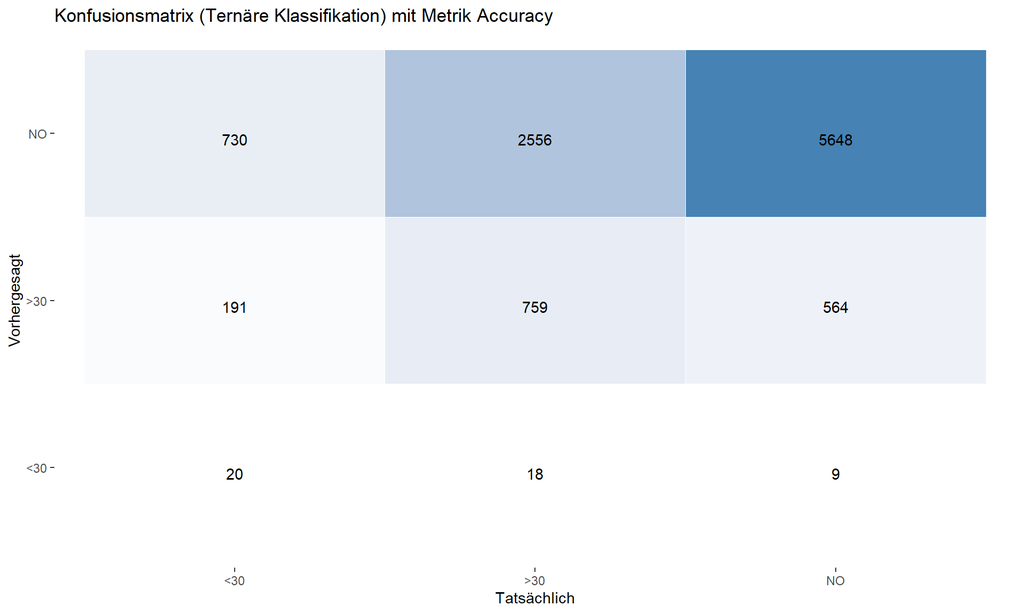

```r
cm_table <- as.data.frame(conf_mat_xgb_ter_acc$table)

ggplot(data = cm_table, aes(x = Reference, y = Prediction)) +
  geom_tile(aes(fill = Freq), color = "white") +
  geom_text(aes(label = Freq), vjust = 1) +
  scale_fill_gradient(low = "white", high = "steelblue") +
  theme(legend.position = "none",
        panel.background = element_rect(fill = "white", color = NA),
        plot.background = element_rect(fill = "white", color = NA)) +
  labs(title = "Konfusionsmatrix (Ternäre Klassifikation) mit Metrik Accuracy",
       x = "Tatsächlich", y = "Vorhergesagt")
```

Wie im vorigen Abschnitt, ist auch hier die Klasse “No” die dominierende Klasse in der Prognose der Zielvariable. Typischerweise für unbalancierten Beobachtungen wird in der Metik Accuracy die dominierende Klasse bevorzugt bzw. überschätzt (siehe z.B. die Anzahl für vorhergesagt “No” und tatsächlich “>30”).

Ein Vergleich der Konfusionsmatrix des XGBoost-Modells mit der Konfusionsmatrix der Multinomialer Logistischer Regression jeweils mit der Metrik *Accuracy* zeigt, dass die beiden kleineren Klassen “<30” und “>30” mit dem XGBoost-Modell deutlich öfters richtig erkannt wurden.

Konfusionsmatrix des XGBoost-Modells mit Metrik *Accuracy*:

```r
conf_mat_xgb_ter_acc$table
```

```
##           Reference
## Prediction  <30  >30   NO
##        <30   20   18    9
##        >30  191  759  564
##        NO   730 2556 5648
```

Konfusionsmatrix der Multinomialer Logistischer Regression mit Metrik *Accuracy*:

```r
conf_mat_multinom_acc$table
```

```
##           Reference
## Prediction  <30  >30   NO
##        <30    5    6    0
##        >30  157  567  401
##        NO   779 2760 5820
```

**Analyse für die Metrik “Balanced Accuracy”**

Für die Berechnung der endgültigen Prognose werden jene Schwellwerte verwendet, für die die Metrik *Balanced Accuracy* maximiert wird. Die folgende Tabelle zeigt eine Übersicht über die 10 Schwellwerte mit den höchsten Werten für diese Metrik.

```r
best_xgb_ter_balacc <- uebersicht %>%
  dplyr::arrange(desc(Balanced_Accuracy)) %>%
  head(10)
best_xgb_ter_balacc
```

```
##      p1   p2  Accuracy Balanced_Accuracy  Macro_F1
## 1  0.10 0.30 0.4477370         0.4487554 0.3965179
## 2  0.15 0.30 0.5166270         0.4474422 0.4316788
## 3  0.10 0.35 0.4742258         0.4463800 0.3981092
## 4  0.15 0.35 0.5509290         0.4448177 0.4393815
## 5  0.10 0.25 0.4062887         0.4413721 0.3730819
## 6  0.10 0.40 0.4909004         0.4413177 0.3869474
## 7  0.15 0.25 0.4666031         0.4394150 0.4015407
## 8  0.20 0.30 0.5381610         0.4348173 0.4252945
## 9  0.15 0.40 0.5694140         0.4345057 0.4275034
## 10 0.10 0.45 0.4950929         0.4323004 0.3655790
```

Prognose der Testdaten und Berechnung der Konfusionsmatrix:

```r
pred_xgb_ter_balacc <- probs_predict(probs_xgb_ter, p1 = best_xgb_ter_balacc$p1[1], p2 = best_xgb_ter_balacc$p2[1])
conf_mat_xgb_ter_balacc <- caret::confusionMatrix(pred_xgb_ter_balacc, test_data_multi$TARGET)
conf_mat_xgb_ter_balacc$table
```

```
##           Reference
## Prediction  <30  >30   NO
##        <30  449 1168 1530
##        >30  281 1335 1776
##        NO   211  830 2915
```

Grafische Darstellung der Konfusionsmatrix:

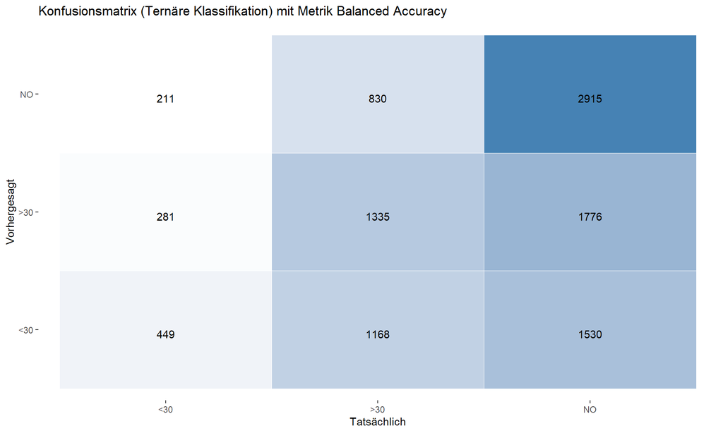

```r
cm_table <- as.data.frame(conf_mat_xgb_ter_balacc$table)

ggplot(data = cm_table, aes(x = Reference, y = Prediction)) +
  geom_tile(aes(fill = Freq), color = "white") +
  geom_text(aes(label = Freq), vjust = 1) +
  scale_fill_gradient(low = "white", high = "steelblue") +
  theme(legend.position = "none",
        panel.background = element_rect(fill = "white", color = NA),
        plot.background = element_rect(fill = "white", color = NA)) +
  labs(title = "Konfusionsmatrix (Ternäre Klassifikation) mit Metrik Balanced Accuracy",
       x = "Tatsächlich", y = "Vorhergesagt")
```

Wieder gelten auch hier dieselben Aussagen wie im vorigen Abschnitt. Die Konfusionsmatrix zeigt, dass im Vergleich zur Metrik *Accuracy* insgesamt weniger Prognosen korrekt sind, allerdings die beiden kleineren aber wichtigeren Klassen “<30” und “>30” deutlich öfters richtig prognostiziert wurden.

Ein Vergleich der Konfusionsmatrix des XGBoost-Modells mit der Konfusionsmatrix der Multinomialer Logistischer Regression jeweils mit der Metrik *Balanced Accuracy* zeigt, dass die Klasse “<30” mit dem XGBoost-Modell deutlich öfters richtig erkannt wurde, die Klassen “>30” und “No” mit der Multinomialer Logistischer Regression.

Konfusionsmatrix des XGBoost-Modells mit Metrik *Balanced Accuracy*:

```r
conf_mat_xgb_ter_balacc$table
```

```
##           Reference
## Prediction  <30  >30   NO
##        <30  449 1168 1530
##        >30  281 1335 1776
##        NO   211  830 2915
```

Konfusionsmatrix der Multinomialer Logistischer Regression mit Metrik *Balanced Accuracy*:

```r
conf_mat_multinom_balacc$table
```

```
##           Reference
## Prediction  <30  >30   NO
##        <30  209  419  483
##        >30  446 1931 2563
##        NO   286  983 3175
```

**Analyse für die Metrik “Macro-F1-Score”**

Für die Berechnung der endgültigen Prognose werden jene Schwellwerte verwendet, für die die Metrik *Macro-F1-Score* maximiert wird. Die folgende Tabelle zeigt eine Übersicht über die 10 Schwellwerte mit den höchsten Werten für diese Metrik.

```r
best_xgb_ter_macf1 <- uebersicht %>%
  dplyr::arrange(desc(Macro_F1)) %>%
  head(10)
best_xgb_ter_macf1
```

```
##      p1   p2  Accuracy Balanced_Accuracy  Macro_F1
## 1  0.15 0.35 0.5509290         0.4448177 0.4393815
## 2  0.20 0.35 0.5752263         0.4319360 0.4348235
## 3  0.15 0.30 0.5166270         0.4474422 0.4316788
## 4  0.25 0.35 0.5852311         0.4284146 0.4293021
## 5  0.15 0.40 0.5694140         0.4345057 0.4275034
## 6  0.20 0.30 0.5381610         0.4348173 0.4252945
## 7  0.20 0.40 0.5942830         0.4199955 0.4233370
## 8  0.30 0.35 0.5894235         0.4254578 0.4229342
## 9  0.25 0.30 0.5463554         0.4306029 0.4185147
## 10 0.25 0.40 0.6038113         0.4153240 0.4174224
```

Prognose der Testdaten und Berechnung der Konfusionsmatrix:

```r
pred_xgb_ter_macf1 <- probs_predict(probs_xgb_ter, p1 = best_xgb_ter_macf1$p1[1], p2 = best_xgb_ter_macf1$p2[1])
conf_mat_xgb_ter_macf1 <- caret::confusionMatrix(pred_xgb_ter_macf1, test_data_multi$TARGET)
conf_mat_xgb_ter_macf1$table
```

```
##           Reference
## Prediction  <30  >30   NO
##        <30  231  448  553
##        >30  318 1412 1529
##        NO   392 1473 4139
```

Grafische Darstellung der Konfusionsmatrix:

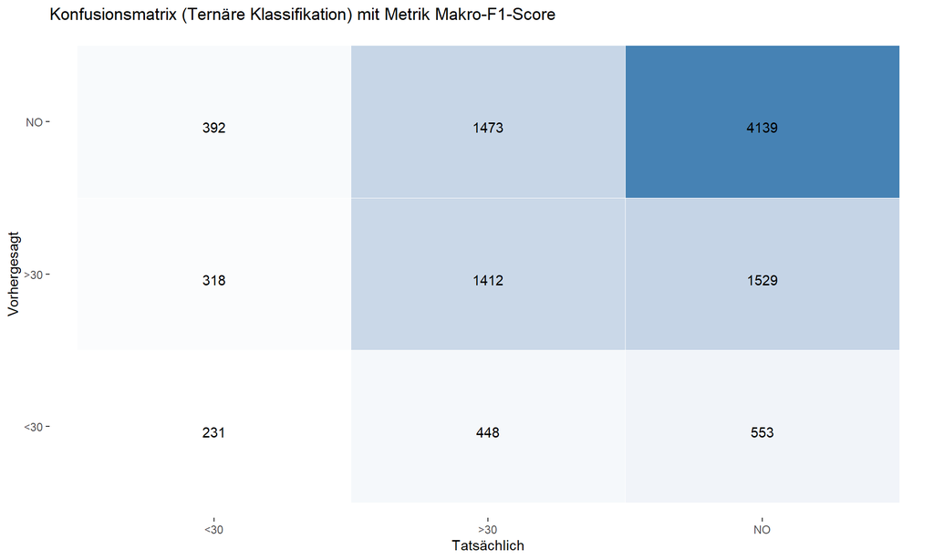

```r
cm_table <- as.data.frame(conf_mat_xgb_ter_macf1$table)

ggplot(data = cm_table, aes(x = Reference, y = Prediction)) +
  geom_tile(aes(fill = Freq), color = "white") +
  geom_text(aes(label = Freq), vjust = 1) +
  scale_fill_gradient(low = "white", high = "steelblue") +
  theme(legend.position = "none",
        panel.background = element_rect(fill = "white", color = NA),
        plot.background = element_rect(fill = "white", color = NA)) +
  labs(title = "Konfusionsmatrix (Ternäre Klassifikation) mit Metrik Makro-F1-Score",
       x = "Tatsächlich", y = "Vorhergesagt")
```

Auch hier zeigt ein Vergleich der Konfusionsmatrix des XGBoost-Modells mit der Konfusionsmatrix der Multinomialer Logistischer Regression jeweils mit der Metrik *Macro-F1-Score*, dass die Klasse “<30” mit dem XGBoost-Modell deutlich öfters richtig erkannt wurde, die Klassen “>30” und “No” mit der Multinomialer Logistischer Regression.

Konfusionsmatrix des XGBoost-Modells mit Metrik *Macro-F1-Score*:

```r
conf_mat_xgb_ter_macf1$table
```

```
##           Reference
## Prediction  <30  >30   NO
##        <30  231  448  553
##        >30  318 1412 1529
##        NO   392 1473 4139
```

Konfusionsmatrix der Multinomialer Logistischer Regression mit Metrik *Macro-F1-Score*:

```r
conf_mat_multinom_macf1$table
```

```
##           Reference
## Prediction  <30  >30   NO
##        <30  129  184  195
##        >30  347 1505 1634
##        NO   465 1644 4392
```

Insgesamt zeigt sich, dass für alle drei betrachteten Metriken das XGBoost-Modell die Klasse “<30” im Vergleich zur Multinomialer Logistischer Regression deutlich häufiger richtig prognostiziert. Falls die Ausmerksamkeit auf dieser Klasse liegt, ist das XGBoost-Modell zu bevorzugen.

## 7.4 d) One-vs-One

Die Aufgabenstellung wird folgendermaßen verstanden und durchgeführt:

- Ausgangsbasis ist das Modell für die ternäre Klassifikation mit Multinomialer Logistischer Regression.
- Für jeweils zwei Ausprägungen der TARGET-Variable (“<30”, “>30”, “No”) werden jene Bebobachtungen aus den Testdaten gefiltert, die eine der beiden Ausprägungen haben.
- Aus dem Modell für die ternäre Klassifikation gibt es für jede Beobachtung eine Wahrscheinlichkeit für die Prognose der beiden Ausprägungen. Die Summe der beiden Wahrscheinlichkeiten ist allerdings nicht 1, da die dritte - nicht betrachtete Ausprägung - in der ternäre Klassifikation ebenfalls eine Wahrscheinlichkeit > 0 hat. Deshalb werden die Wahrscheinlichkeiten der beiden gewählten Ausprägungen für jede Beobachtung auf die Summe 1 normiert.
- Die Zielvariable im gefilterten Testbestand wird 0 / 1 codiert.
- Der AUC-Wert wird aus dem gefilterten Datensatz und den normierten Wahrscheinlichkeiten berechnet.

Die nachfolgende Funktion *one_vs_one* führt die oben beschriebenen Schritte für zwei vorgebenen Spalten *Spalte_1* und *Spalte_2* durch. Die Spaltennummer steht einerseits für die Spalte der im vorigen Abschnitt berechneten Wahrscheinlichkeiten *probs_multinom* für die einzelnen Ausprägungen / Klassen in der Multinomialer Logistischer Regression …

```r
head(probs_multinom, 10)
```

```
##           <30       >30        NO
## 1  0.05785711 0.3027690 0.6393739
## 2  0.07528868 0.3755198 0.5491915
## 3  0.13925277 0.5642292 0.2965180
## 4  0.07019649 0.3132891 0.6165144
## 5  0.08137210 0.3253073 0.5933206
## 6  0.07723860 0.3579414 0.5648200
## 7  0.06678516 0.3045283 0.6286865
## 8  0.08789913 0.3660143 0.5460866
## 9  0.10609336 0.3795579 0.5143488
## 10 0.07991399 0.5556373 0.3644487
```

… andererseits für die Position der Ausprägung in den Levels der Zielvariablen:

```r
(factor_levels <- levels(test_data_multi$TARGET))
```

```
## [1] "<30" ">30" "NO"
```

Definition der Funktion *one_vs_one*:

```r
one_vs_one <- function(Spalte_1, Spalte_2) {
  rueckgabe <- list()

  Klasse_0 <- factor_levels[Spalte_1]
  Klasse_1 <- factor_levels[Spalte_2]

  in_klassen <- test_data_multi$TARGET %in% c(Klasse_0,Klasse_1) # Prüft, ob die Beobachtung in eine der beiden Klassen fällt
  tmp_test_data_multi <-  test_data_multi[in_klassen,] %>%
    dplyr::mutate(TARGET_klasse = ifelse(TARGET == Klasse_0, 0, 1))

  # Die entsprechenden Spalten aus der Wahrscheinlichkeits-Tabelle werden gefiltert und jede Zeile auf 1 normiert
  tmp_probs <- probs_multinom[in_klassen,c(Klasse_0,Klasse_1)]
  tmp_probs <- tmp_probs / rowSums(tmp_probs)

  # Für die Berechnung der AUC wird die zweite Spalte berechnet, da hier die Wahrscheinlichkeit für die
  # TARGET_klasse "1" steht.
  AUC <- MLmetrics::AUC(tmp_probs[,2], tmp_test_data_multi$TARGET_klasse)

  predicted_class <- ifelse(tmp_probs[,2] >= 0.2, 1, 0)
  conf_mat <- caret::confusionMatrix(factor(predicted_class), factor(tmp_test_data_multi$TARGET_klasse), positive = "1")
  conf_mat$table

  rueckgabe_df <- data.frame(Klasse_0 = Klasse_0,
                             Klasse_1 = Klasse_1,
                             Anzahl = sum(in_klassen),
                             AUC = AUC)

  print(rueckgabe_df)

  rueckgabe$conf_mat <- conf_mat
  rueckgabe$df <- rueckgabe_df

  return(rueckgabe)
}
```

**Binäre Klassifikation der Klassen <30 und >30**

```r
tmp_1_2 <- one_vs_one(1,2)
```

```
##   Klasse_0 Klasse_1 Anzahl       AUC
## 1      <30      >30   4274 0.5954885
```

**Binäre Klassifikation der Klassen <30 und NO**

```r
tmp_3_1 <- one_vs_one(3,1)
```

```
##   Klasse_0 Klasse_1 Anzahl      AUC
## 1       NO      <30   7162 0.671169
```

Der Aufruf erfolgt in Form (3,1), damit wie in Abschnitt *R1 g)* der Klasse “No” der Wert 0 und der Klasse “<30” der Wert 1 zugewiesen wird. Damit sind die Ergebnisse (Konfusionsmatrix) mit den Ergebnissen aus Aufgabe *R4* vergleichbar.

Das Modell für die ternäre Klassifikation zeigt - eingeschränkt auf die beiden Ausprägungen in Aufgabe *R4* - mit 0.671169 einen geringfügig höheren AUC-Wert im Vergleich zum entsprechenden binären Modell mit 0.6703056.

Die beiden Modelle liefern eine ähnliche Aufteilung der Konfusionsmatrix, wie folgende Auswertungen zeigen:

*Konfusionsmatrix der logistischen Regression aus Aufgabe “R4”*:

```r
conf_mat_glm$table
```

```
##           Reference
## Prediction    0    1
##          0 5484  660
##          1  737  281
```

*Konfusionsmatrix der “one_vs_one”-Analyse*:

```r
tmp_3_1$conf_mat$table
```

```
##           Reference
## Prediction    0    1
##          0 5457  655
##          1  764  286
```

Eine nähere Betrachtung zeigt, dass auch andere Gütemaße (Sensitifität, Spezifität, …) ähnlich Größenordnungen aufweisen:

*Gütemaße der logistischen Regression aus Aufgabe “R4”*:

```r
conf_mat_glm
```

```
## Confusion Matrix and Statistics
##
##           Reference
## Prediction    0    1
##          0 5484  660
##          1  737  281
##
##                Accuracy : 0.8049
##                  95% CI : (0.7956, 0.8141)
##     No Information Rate : 0.8686
##     P-Value [Acc > NIR] : 1.00000
##
##                   Kappa : 0.1741
##
##  Mcnemar's Test P-Value : 0.04202
##
##             Sensitivity : 0.29862
##             Specificity : 0.88153
##          Pos Pred Value : 0.27603
##          Neg Pred Value : 0.89258
##              Prevalence : 0.13139
##          Detection Rate : 0.03923
##    Detection Prevalence : 0.14214
##       Balanced Accuracy : 0.59007
##
##        'Positive' Class : 1
##
```

*Gütemaße der “one_vs_one”-Analyse*:

```r
tmp_3_1$conf_mat
```

```
## Confusion Matrix and Statistics
##
##           Reference
## Prediction    0    1
##          0 5457  655
##          1  764  286
##
##                Accuracy : 0.8019
##                  95% CI : (0.7924, 0.811)
##     No Information Rate : 0.8686
##     P-Value [Acc > NIR] : 1.000000
##
##                   Kappa : 0.1726
##
##  Mcnemar's Test P-Value : 0.004143
##
##             Sensitivity : 0.30393
##             Specificity : 0.87719
##          Pos Pred Value : 0.27238
##          Neg Pred Value : 0.89283
##              Prevalence : 0.13139
##          Detection Rate : 0.03993
##    Detection Prevalence : 0.14661
##       Balanced Accuracy : 0.59056
##
##        'Positive' Class : 1
##
```

**Binäre Klassifikation der Klassen >30 und NO**

```r
tmp_3_2 <- one_vs_one(3,2)
```

```
##   Klasse_0 Klasse_1 Anzahl      AUC
## 1       NO      >30   9554 0.656781
```

Die drei Ergebnisse zeigen, dass die Einschränkung des Modells für ternäre Klassifikation auf die binäre Klassifikation für alle gewählten Klassenpaare einen hohen AUC-Wert liefert. Lediglich die erste Auswertung für die Kombination der kleineren Klassen “<30” und “>30” fällt mit ein wenig ab, liefert aber dennoch einen relativ hohen Wert. Dies zeigt, dass das Modells für die ternäre Klassifikation keinen “systematischen Fehler” enthält und Beziehungen zwischen zwei Klassen zufriedenstellend berücksichtig.

Speziell der Vergleich mit der binären logistischen Regression aus Aufgabe *R4* zeigt, dass die Ergebnisse der beiden Modell weitgehend übereinstimmen.

## 7.5 e) Fazit

Die Analysen in den Abschnitten *R3* und *R4* zeigen, dass alle betrachteten Modelle für die binäre Klassifikation ähnliche Werte im Gütemaß AUC haben. Den höchsten AUC-Wert liefert das XGBoost-Modell mit 0.6860268. Der Grund könnte sein, dass im XGBoost-Modell die Interaktionen der Merkmale in natürlicher Weise berücksichtigt werden, während sie in allen anderen Modellen von außen vorgegeben werden müssen. Zusätzlich wird für numerische Variablen im XGBoost-Modell kein linearer Zusammenhang modelliert, sondern ein allgemeinerer. Allerdings ist es im oben konstruierten XGBoost-Modell im Vergleich zu den restlichen Modellen schwieriger, den Einfluss der einzelnen Ausprägungen eines kategoriellen Merkmals auf die Zielvariable zu bewerten. Eine Möglichkeit, diese Bewertung zu erhalten wäre, ein One-Hot-Encoding der kategoriellen Merkmale zu verwenden, da in diesem Fall jede Ausprägung einzel im Modell berücksichtigt wird. In allen anderen Modellen erfolgt die Bewertung der einzelnen Ausprägungen der kategoriellen Merkmale direkt, da für jede Ausprägung ein eigener Koeffizient berechnet wird und darauf direkt der Einfluss auf die Zielvariable ablesbar ist.

Soll das Modell nicht nur zur Prognose der Wahrscheinlichkeit einer frühzeitigen Wiedereinweisung verwendet werden, sondern steht die Analyse der Einflussgrößen und Treiber für die frühzeitigen Wiedereinweisung im Vordergrund, so wäre eine Logistische Regressionen mit Interaktionen oder ein GAM-Modell die erste Wahl.

Die beiden Modell für die ternäre Klassifikation haben im Vergleich zur binären Klassifikation den Vorteil, dass mit ihnen weitergreifende Analysen möglich sind. So lassen sich nicht nur Treiber für eine frühzeitige Wiedereinweisung “<30” analysieren, sondern die Treiber für eine generelle Wiedereinweisung. Wie die Ergebnisse aus Abschnitt *d)* zeigen, können mit diesen allgemeineren Modellen auch Aussagen hoher Güte für das Verhalten paarweise Klassen getroffen werden. Allerdings lassen sich aus den allgemeineren Modellen nur unzureichend Einflussgrößen und Treiber für paarweise Klassenverhalten ableiten, wie die folgende Analyse zeigt. Die Funktion *Var_Imp_lm_Plot* dient dabei zur Darstellung der Feature Importance in logistischen Regressionsmodellen.

```r
Var_Imp_lm_Plot <- function(vi_in, n = 10, clusters = 4) {
  Imp_lm <- list()
  Imp_lm$Feature <- rownames(vi_in)
  Imp_lm$Gain <- vi_in$Overall / sum(vi_in$Overall)
  Imp_lm$Cover <- Imp_lm$Gain
  Imp_lm$Frequency <- Imp_lm$Gain
  Imp_lm$Importance <- Imp_lm$Gain
  Imp_lm <- data.table::as.data.table(Imp_lm)
  xgboost::xgb.ggplot.importance(Imp_lm, top_n = n, n_clusters = clusters)
}
```

**Feature Importance der Logistischen Regression ohne Interaktionen** aus Abschnitt *R4 a)*:

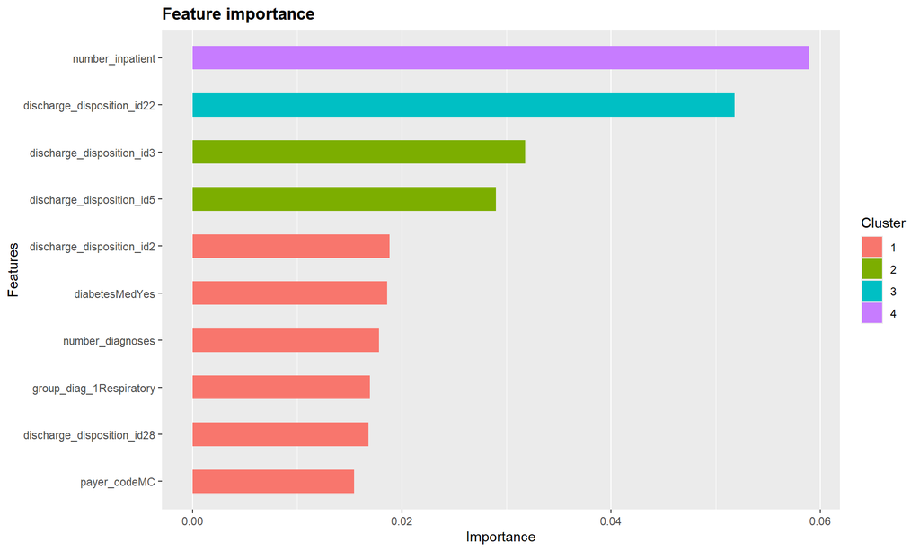

```r
vi_glm <- caret::varImp(glm_model, scale = FALSE) %>%
    dplyr::arrange(desc(Overall))
Var_Imp_lm_Plot(vi_glm)
```

**Feature Importance der Ternären Multinomialen Logistischen Regression** aus Abschnitt *R6 b)*:

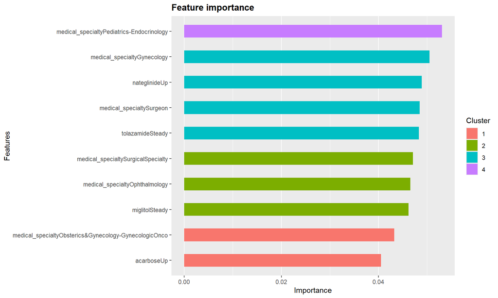

```r
vi_multilog <- caret::varImp(multilog_model, scale = FALSE) %>%
  dplyr::arrange(desc(Overall))
Var_Imp_lm_Plot(vi_multilog)
```

Ein Vergleich der beiden Grafiken zeigt, dass unterschiedliche Hauptreiber für die beiden Modelle gefunden wurden. Der Grund liegt vor allem darin, dass das Modell für ternäre Klassifikation auch Einflussgrößen der dritten Klasse “>30” enthält. Diese Klasse wird auch von den zusätzlichen in der Modellierung berücksichten Beobachtungen getrieben.

Eine allgemeine bzw. endgültige Empfehlung eines Modells ist schwierig und hängt vom Ziel der Modellanwendung ab. Bezogen auf die frühzeitige Wiedereinweisung (d.h. die Klasse “<30”), liefern die XGBoost-Modelle sowohl für binäre als auch für ternäre Klassifikation die besseren Prognoseergebnisse, (auch) da sie Interaktionen der Merkmale im Modell berücksichtigen. Allerdings ist es schwieriger, den Einfluss der einzelnen Ausprägungen eines kategoriellen Merkmals auf die Zielvariable zu bewerten.

Ist das Ziel, nicht nur eine möglichst zuverlässige Prognose der Wahrscheinlichkeit einer frühzeitigen Wiedereinweisung (“<30”) zu erhalten, sondern auch Ausschlüsse über die Einflussgrößen und Treiber zu bekommen, so ist ein binäres Klassifikationsmodell einem ternären Klassenmodell vorzuziehen. In diesem Fall wäre es auch überlegenswert, die gesamte Datenbasis zu verwenden und die Klasse “>30” der Klasse “NO” gleichzusetzen, um alle vorhandenen Beobachtungen nützen zu können. Für die Ableitung der Einflussgrößen und Treiber wäre wieder eine Logistische Regressionen mit Interaktionen oder ein GAM-Modell die erste Wahl.

[session information not shown]